# ML Project

Brendan Chua

11/12/2020

## R Markdown

```r
library(dplyr)
```

```r
library(ggplot2) # Load ggplot2 for visualizations
library(naniar) # Load nanair for missing data visualization
library(OneR) # Load OneR for binning function
library(mice) # Load mice for missing data inputation
library(glmnet)
library(plotmo)
library(readr)
SimpleDataSetWithNewTarget <- read_csv("../Desktop/SimpleDataSetWithNewTarget.csv")
summary(SimpleDataSetWithNewTarget)
```

```
##  artist_familiarity artist_hotttnesss  artist_id         artist_latitude
##  Min.   :0.0000     Min.   :0.0000    Length:10001       Min.   :-41.28
##  1st Qu.:0.4676     1st Qu.:0.3253    Class :character   1st Qu.: 33.75
##  Median :0.5637     Median :0.3808    Mode  :character   Median : 39.00
##  Mean   :0.5655     Mean   :0.3856                       Mean   : 37.16
##  3rd Qu.:0.6680     3rd Qu.:0.4539                       3rd Qu.: 43.65
##  Max.   :1.0000     Max.   :1.0825                       Max.   : 69.65
##  NA's   :4                                               NA's   :6259
##  artist_location    artist_longitude   artist_name           duration
##  Length:10001       Min.   :-162.436   Length:10001       Min.   :   1.044
##  Class :character   1st Qu.: -93.292   Class :character   1st Qu.: 176.039
##  Mode  :character   Median : -80.237   Mode  :character   Median : 223.059
##                     Mean   : -63.933                      Mean   : 238.512
##                     3rd Qu.:  -9.401                      3rd Qu.: 276.375
##                     Max.   : 174.767                      Max.   :1819.768
##                     NA's   :6259
##  end_of_fade_in         key         key_confidence      loudness
##  Min.   : 0.0000   Min.   : 0.000   Min.   :0.0000   Min.   :-51.643
##  1st Qu.: 0.0000   1st Qu.: 2.000   1st Qu.:0.2250   1st Qu.:-13.163
##  Median : 0.1990   Median : 5.000   Median :0.4690   Median : -9.380
##  Mean   : 0.7586   Mean   : 5.276   Mean   :0.4496   Mean   :-10.485
##  3rd Qu.: 0.4210   3rd Qu.: 8.000   3rd Qu.:0.6590   3rd Qu.: -6.531
##  Max.   :43.1190   Max.   :11.000   Max.   :1.0000   Max.   :  0.566
##
##       mode        mode_confidence    release          song_hotttnesss
##  Min.   :0.0000   Min.   :0.0000   Length:10001       Min.   :0.000
##  1st Qu.:0.0000   1st Qu.:0.3600   Class :character   1st Qu.:0.000
##  Median :1.0000   Median :0.4870   Mode  :character   Median :0.360
##  Mean   :0.6911   Mean   :0.4778                      Mean   :0.343
##  3rd Qu.:1.0000   3rd Qu.:0.6060                      3rd Qu.:0.538
##  Max.   :1.0000   Max.   :1.0000                      Max.   :1.000
##                                                       NA's   :4352
##  start_of_fade_out      tempo        time_signature  time_signature_confidence
##  Min.   :   1.044   Min.   :  0.00   Min.   :0.000   Min.   :0.0000
##  1st Qu.: 168.856   1st Qu.: 96.97   1st Qu.:3.000   1st Qu.:0.0980
##  Median : 213.879   Median :120.16   Median :4.000   Median :0.5510
##  Mean   : 229.980   Mean   :122.92   Mean   :3.565   Mean   :0.5099
##  3rd Qu.: 266.292   3rd Qu.:144.02   3rd Qu.:4.000   3rd Qu.:0.8640
##  Max.   :1813.426   Max.   :262.83   Max.   :7.000   Max.   :1.0000
##
##     title                year            bbhot
##  Length:10001       Min.   :   0.0   Min.   :0.0000
##  Class :character   1st Qu.:   0.0   1st Qu.:0.0000
##  Mode  :character   Median :   0.0   Median :0.0000
##                     Mean   : 934.8   Mean   :0.1192
##                     3rd Qu.:2000.0   3rd Qu.:0.0000
##                     Max.   :2010.0   Max.   :1.0000
##
```

```r
str(SimpleDataSetWithNewTarget)
```

```
## tibble [10,001 × 23] (S3: spec_tbl_df/tbl_df/tbl/data.frame)
##  $ artist_familiarity       : num [1:10001] 0.78 0.582 0.631 0.487 0.63 ...
##  $ artist_hotttnesss        : num [1:10001] 0.574 0.402 0.417 0.343 0.454 ...
##  $ artist_id                : chr [1:10001] "ARMQHX71187B9890D3" "ARD7TVE1187B99BFB1" "ARMJAGH1187FB546F3" "ARKRRTF1187B9984DA" ...
##  $ artist_latitude          : num [1:10001] NA NA 35.1 NA NA ...
##  $ artist_location          : chr [1:10001] "Atlanta, GA" "California - LA" "Memphis, TN" NA ...
##  $ artist_longitude         : num [1:10001] NA NA -90 NA NA ...
##  $ artist_name              : chr [1:10001] "Mastodon" "Casual" "The Box Tops" "Sonora Santanera" ...
##  $ duration                 : num [1:10001] 280 219 148 177 233 ...
##  $ end_of_fade_in           : num [1:10001] 0.238 0.247 0.148 0.282 0 ...
##  $ key                      : num [1:10001] 5 1 6 8 0 2 5 1 4 4 ...
##  $ key_confidence           : num [1:10001] 0.555 0.736 0.169 0.643 0.751 0.092 0.635 0 0 0.717 ...
##  $ loudness                 : num [1:10001] -3.31 -11.2 -9.84 -9.69 -9.01 ...
##  $ mode                     : num [1:10001] 1 0 0 1 1 1 1 1 0 1 ...
##  $ mode_confidence          : num [1:10001] 0.5 0.636 0.43 0.565 0.749 0.371 0.557 0 0.16 0.652 ...
##  $ release                  : chr [1:10001] "Call of the Mastodon" "Fear Itself" "Dimensions" "Las Numero 1 De La Sonora Santanera" ...
##  $ song_hotttnesss          : num [1:10001] 0.598 0.602 NA NA NA ...
##  $ start_of_fade_out        : num [1:10001] 276 219 138 172 217 ...
##  $ tempo                    : num [1:10001] 173.2 92.2 121.3 100.1 119.3 ...
##  $ time_signature           : num [1:10001] 5 4 4 1 4 4 3 1 3 4 ...
##  $ time_signature_confidence: num [1:10001] 0.12 0.778 0.384 0 0 0.562 0.454 0 0.408 0.487 ...
##  $ title                    : chr [1:10001] "Deep Sea Creature" "I Didn't Mean To" "Soul Deep" "Amor De Cabaret" ...
##  $ year                     : num [1:10001] 2001 0 1969 0 1982 ...
##  $ bbhot                    : num [1:10001] 0 0 1 0 0 0 0 0 0 0 ...
##  - attr(*, "spec")=
##   .. cols(
##   ..   artist_familiarity = col_double(),
##   ..   artist_hotttnesss = col_double(),
##   ..   artist_id = col_character(),
##   ..   artist_latitude = col_double(),
##   ..   artist_location = col_character(),
##   ..   artist_longitude = col_double(),
##   ..   artist_name = col_character(),
##   ..   duration = col_double(),
##   ..   end_of_fade_in = col_double(),
##   ..   key = col_double(),
##   ..   key_confidence = col_double(),
##   ..   loudness = col_double(),
##   ..   mode = col_double(),
##   ..   mode_confidence = col_double(),
##   ..   release = col_character(),
##   ..   song_hotttnesss = col_double(),
##   ..   start_of_fade_out = col_double(),
##   ..   tempo = col_double(),
##   ..   time_signature = col_double(),
##   ..   time_signature_confidence = col_double(),
##   ..   title = col_character(),
##   ..   year = col_double(),
##   ..   bbhot = col_double()
##   .. )
```

```r
head(SimpleDataSetWithNewTarget)
```

```
## # A tibble: 6 x 23
##   artist_familiar… artist_hotttnes… artist_id artist_latitude artist_location
##              <dbl>            <dbl> <chr>               <dbl> <chr>
## 1            0.780            0.574 ARMQHX71…            NA   Atlanta, GA
## 2            0.582            0.402 ARD7TVE1…            NA   California - LA
## 3            0.631            0.417 ARMJAGH1…            35.1 Memphis, TN
## 4            0.487            0.343 ARKRRTF1…            NA   <NA>
## 5            0.630            0.454 AR7G5I41…            NA   London, England
## 6            0.651            0.402 ARXR32B1…            NA   <NA>
## # … with 18 more variables: artist_longitude <dbl>, artist_name <chr>,
## #   duration <dbl>, end_of_fade_in <dbl>, key <dbl>, key_confidence <dbl>,
## #   loudness <dbl>, mode <dbl>, mode_confidence <dbl>, release <chr>,
## #   song_hotttnesss <dbl>, start_of_fade_out <dbl>, tempo <dbl>,
## #   time_signature <dbl>, time_signature_confidence <dbl>, title <chr>,
## #   year <dbl>, bbhot <dbl>
```

```r
tail(SimpleDataSetWithNewTarget)
```

```
## # A tibble: 6 x 23
##   artist_familiar… artist_hotttnes… artist_id artist_latitude artist_location
##              <dbl>            <dbl> <chr>               <dbl> <chr>
## 1            0.607            0.401 ARDK0551…            31.3 Marlin, TX
## 2            0.723            0.500 AR4C6V01…            39.6 Portugal
## 3            0.512            0.410 AR9JLBU1…           -34.0 Port Elizabeth…
## 4            0.434            0.290 ARS1DCR1…            NA   <NA>
## 5            0.334            0.217 ARAGMIV1…            NA   <NA>
## 6            0.609            0.509 ARYXOV81…            NA   <NA>
## # … with 18 more variables: artist_longitude <dbl>, artist_name <chr>,
## #   duration <dbl>, end_of_fade_in <dbl>, key <dbl>, key_confidence <dbl>,
## #   loudness <dbl>, mode <dbl>, mode_confidence <dbl>, release <chr>,
## #   song_hotttnesss <dbl>, start_of_fade_out <dbl>, tempo <dbl>,
## #   time_signature <dbl>, time_signature_confidence <dbl>, title <chr>,
## #   year <dbl>, bbhot <dbl>
```

```r
dim(SimpleDataSetWithNewTarget)
```

```
## [1] 10001    23
```

```r
MusicDatasetMSD <- SimpleDataSetWithNewTarget
colnames(MusicDatasetMSD)
```

```
##  [1] "artist_familiarity"        "artist_hotttnesss"
##  [3] "artist_id"                 "artist_latitude"
##  [5] "artist_location"           "artist_longitude"
##  [7] "artist_name"               "duration"
##  [9] "end_of_fade_in"            "key"
## [11] "key_confidence"            "loudness"
## [13] "mode"                      "mode_confidence"
## [15] "release"                   "song_hotttnesss"
## [17] "start_of_fade_out"         "tempo"
## [19] "time_signature"            "time_signature_confidence"
## [21] "title"                     "year"
## [23] "bbhot"
```

```r
str(MusicDatasetMSD)
```

```
## tibble [10,001 × 23] (S3: spec_tbl_df/tbl_df/tbl/data.frame)
##  $ artist_familiarity       : num [1:10001] 0.78 0.582 0.631 0.487 0.63 ...
##  $ artist_hotttnesss        : num [1:10001] 0.574 0.402 0.417 0.343 0.454 ...
##  $ artist_id                : chr [1:10001] "ARMQHX71187B9890D3" "ARD7TVE1187B99BFB1" "ARMJAGH1187FB546F3" "ARKRRTF1187B9984DA" ...
##  $ artist_latitude          : num [1:10001] NA NA 35.1 NA NA ...
##  $ artist_location          : chr [1:10001] "Atlanta, GA" "California - LA" "Memphis, TN" NA ...
##  $ artist_longitude         : num [1:10001] NA NA -90 NA NA ...
##  $ artist_name              : chr [1:10001] "Mastodon" "Casual" "The Box Tops" "Sonora Santanera" ...
##  $ duration                 : num [1:10001] 280 219 148 177 233 ...
##  $ end_of_fade_in           : num [1:10001] 0.238 0.247 0.148 0.282 0 ...
##  $ key                      : num [1:10001] 5 1 6 8 0 2 5 1 4 4 ...
##  $ key_confidence           : num [1:10001] 0.555 0.736 0.169 0.643 0.751 0.092 0.635 0 0 0.717 ...
##  $ loudness                 : num [1:10001] -3.31 -11.2 -9.84 -9.69 -9.01 ...
##  $ mode                     : num [1:10001] 1 0 0 1 1 1 1 1 0 1 ...
##  $ mode_confidence          : num [1:10001] 0.5 0.636 0.43 0.565 0.749 0.371 0.557 0 0.16 0.652 ...
##  $ release                  : chr [1:10001] "Call of the Mastodon" "Fear Itself" "Dimensions" "Las Numero 1 De La Sonora Santanera" ...
##  $ song_hotttnesss          : num [1:10001] 0.598 0.602 NA NA NA ...
##  $ start_of_fade_out        : num [1:10001] 276 219 138 172 217 ...
##  $ tempo                    : num [1:10001] 173.2 92.2 121.3 100.1 119.3 ...
##  $ time_signature           : num [1:10001] 5 4 4 1 4 4 3 1 3 4 ...
##  $ time_signature_confidence: num [1:10001] 0.12 0.778 0.384 0 0 0.562 0.454 0 0.408 0.487 ...
##  $ title                    : chr [1:10001] "Deep Sea Creature" "I Didn't Mean To" "Soul Deep" "Amor De Cabaret" ...
##  $ year                     : num [1:10001] 2001 0 1969 0 1982 ...
##  $ bbhot                    : num [1:10001] 0 0 1 0 0 0 0 0 0 0 ...
##  - attr(*, "spec")=
##   .. cols(
##   ..   artist_familiarity = col_double(),
##   ..   artist_hotttnesss = col_double(),
##   ..   artist_id = col_character(),
##   ..   artist_latitude = col_double(),
##   ..   artist_location = col_character(),
##   ..   artist_longitude = col_double(),
##   ..   artist_name = col_character(),
##   ..   duration = col_double(),
##   ..   end_of_fade_in = col_double(),
##   ..   key = col_double(),
##   ..   key_confidence = col_double(),
##   ..   loudness = col_double(),
##   ..   mode = col_double(),
##   ..   mode_confidence = col_double(),
##   ..   release = col_character(),
##   ..   song_hotttnesss = col_double(),
##   ..   start_of_fade_out = col_double(),
##   ..   tempo = col_double(),
##   ..   time_signature = col_double(),
##   ..   time_signature_confidence = col_double(),
##   ..   title = col_character(),
##   ..   year = col_double(),
##   ..   bbhot = col_double()
##   .. )
```

#Rename variables

```r
MusicDatasetMSD <- MusicDatasetMSD %>%
  rename(artist_hotness = artist_hotttnesss) %>%
  rename(song_hotness = song_hotttnesss) %>%
  rename(BillboardHot = bbhot)
```

#Visualize missing data

```r
feature_variables <- names(MusicDatasetMSD)[]
summary(MusicDatasetMSD[,feature_variables])
```

```
##  artist_familiarity artist_hotness    artist_id         artist_latitude
##  Min.   :0.0000     Min.   :0.0000   Length:10001       Min.   :-41.28
##  1st Qu.:0.4676     1st Qu.:0.3253   Class :character   1st Qu.: 33.75
##  Median :0.5637     Median :0.3808   Mode  :character   Median : 39.00
##  Mean   :0.5655     Mean   :0.3856                      Mean   : 37.16
##  3rd Qu.:0.6680     3rd Qu.:0.4539                      3rd Qu.: 43.65
##  Max.   :1.0000     Max.   :1.0825                      Max.   : 69.65
##  NA's   :4                                              NA's   :6259
##  artist_location    artist_longitude   artist_name           duration
##  Length:10001       Min.   :-162.436   Length:10001       Min.   :   1.044
##  Class :character   1st Qu.: -93.292   Class :character   1st Qu.: 176.039
##  Mode  :character   Median : -80.237   Mode  :character   Median : 223.059
##                     Mean   : -63.933                      Mean   : 238.512
##                     3rd Qu.:  -9.401                      3rd Qu.: 276.375
##                     Max.   : 174.767                      Max.   :1819.768
##                     NA's   :6259
##  end_of_fade_in         key         key_confidence      loudness
##  Min.   : 0.0000   Min.   : 0.000   Min.   :0.0000   Min.   :-51.643
##  1st Qu.: 0.0000   1st Qu.: 2.000   1st Qu.:0.2250   1st Qu.:-13.163
##  Median : 0.1990   Median : 5.000   Median :0.4690   Median : -9.380
##  Mean   : 0.7586   Mean   : 5.276   Mean   :0.4496   Mean   :-10.485
##  3rd Qu.: 0.4210   3rd Qu.: 8.000   3rd Qu.:0.6590   3rd Qu.: -6.531
##  Max.   :43.1190   Max.   :11.000   Max.   :1.0000   Max.   :  0.566
##
##       mode        mode_confidence    release           song_hotness
##  Min.   :0.0000   Min.   :0.0000   Length:10001       Min.   :0.000
##  1st Qu.:0.0000   1st Qu.:0.3600   Class :character   1st Qu.:0.000
##  Median :1.0000   Median :0.4870   Mode  :character   Median :0.360
##  Mean   :0.6911   Mean   :0.4778                      Mean   :0.343
##  3rd Qu.:1.0000   3rd Qu.:0.6060                      3rd Qu.:0.538
##  Max.   :1.0000   Max.   :1.0000                      Max.   :1.000
##                                                       NA's   :4352
##  start_of_fade_out      tempo        time_signature  time_signature_confidence
##  Min.   :   1.044   Min.   :  0.00   Min.   :0.000   Min.   :0.0000
##  1st Qu.: 168.856   1st Qu.: 96.97   1st Qu.:3.000   1st Qu.:0.0980
##  Median : 213.879   Median :120.16   Median :4.000   Median :0.5510
##  Mean   : 229.980   Mean   :122.92   Mean   :3.565   Mean   :0.5099
##  3rd Qu.: 266.292   3rd Qu.:144.02   3rd Qu.:4.000   3rd Qu.:0.8640
##  Max.   :1813.426   Max.   :262.83   Max.   :7.000   Max.   :1.0000
##
##     title                year         BillboardHot
##  Length:10001       Min.   :   0.0   Min.   :0.0000
##  Class :character   1st Qu.:   0.0   1st Qu.:0.0000
##  Mode  :character   Median :   0.0   Median :0.0000
##                     Mean   : 934.8   Mean   :0.1192
##                     3rd Qu.:2000.0   3rd Qu.:0.0000
##                     Max.   :2010.0   Max.   :1.0000
##
```

#I am interested in song_hotness, artist_hotness, and artist familiarity to conduct my initial analysis and visualisation. But I will want to visualize if there’s any missing first.

#Visualize missing data

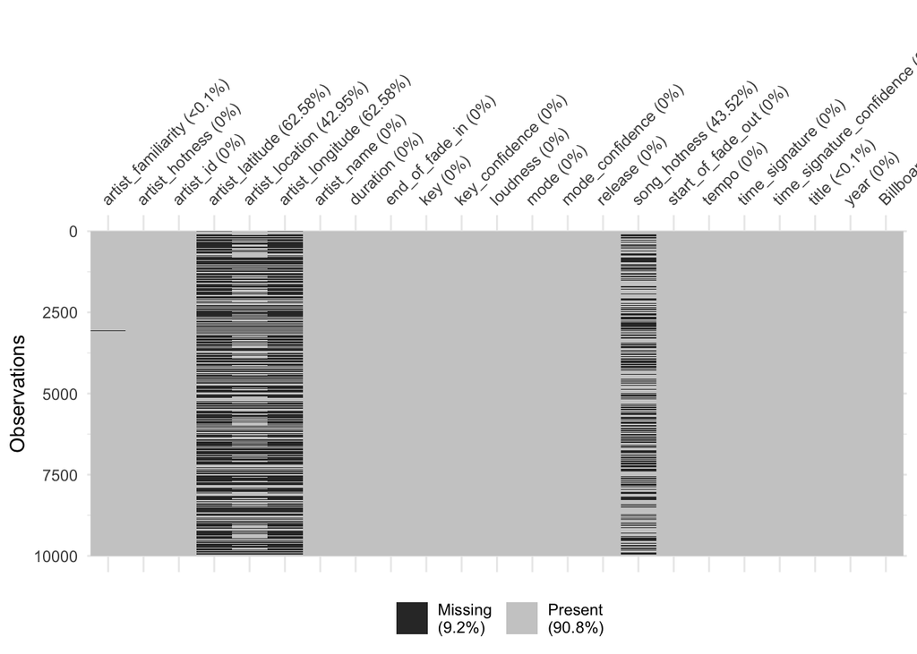

```r
vis_miss(MusicDatasetMSD[, feature_variables])
```

#Checking missing data for song hotness

```r
summary(MusicDatasetMSD$BillboardHot[is.na(MusicDatasetMSD$song_hotness)])
```

```
##    Min. 1st Qu.  Median    Mean 3rd Qu.    Max.
##  0.0000  0.0000  0.0000  0.1195  0.0000  1.0000
```

```r
summary(MusicDatasetMSD$BillboardHot[!is.na(MusicDatasetMSD$song_hotness)])
```

```
##    Min. 1st Qu.  Median    Mean 3rd Qu.    Max.
##   0.000   0.000   0.000   0.119   0.000   1.000
```

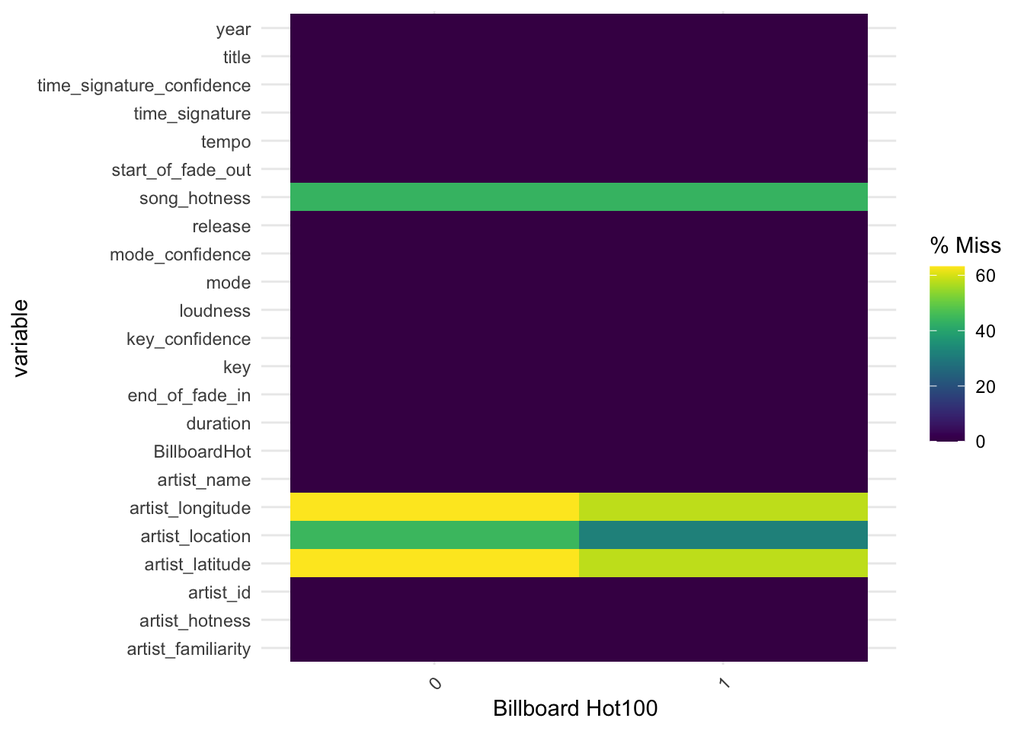

```r
t_bins <- bin(MusicDatasetMSD$BillboardHot, nbins = 2, method = "length") # Bin response variable
plot_dat <- cbind.data.frame(t_bins, MusicDatasetMSD[, feature_variables])
gg_miss_fct(x = plot_dat, fct = t_bins) +
  labs(x = "Billboard Hot100 ")
```

#There is too many missing data for song hotness, artist latitude, artist longitude, so I am going to drop those variables.

#Drop artist latitude

```r
MusicDatasetMSD <- MusicDatasetMSD[,-(4:4)]
```

#Drop artist longitude

```r
MusicDatasetMSD <- MusicDatasetMSD[,-(5:5)]
```

#Drop song hotness

```r
MusicDatasetMSD <- MusicDatasetMSD[,-(14:14)]
```

```r
feature_variables <- names(MusicDatasetMSD)[]
summary(MusicDatasetMSD[,feature_variables])
```

```
##  artist_familiarity artist_hotness    artist_id         artist_location
##  Min.   :0.0000     Min.   :0.0000   Length:10001       Length:10001
##  1st Qu.:0.4676     1st Qu.:0.3253   Class :character   Class :character
##  Median :0.5637     Median :0.3808   Mode  :character   Mode  :character
##  Mean   :0.5655     Mean   :0.3856
##  3rd Qu.:0.6680     3rd Qu.:0.4539
##  Max.   :1.0000     Max.   :1.0825
##  NA's   :4
##  artist_name           duration        end_of_fade_in         key
##  Length:10001       Min.   :   1.044   Min.   : 0.0000   Min.   : 0.000
##  Class :character   1st Qu.: 176.039   1st Qu.: 0.0000   1st Qu.: 2.000
##  Mode  :character   Median : 223.059   Median : 0.1990   Median : 5.000
##                     Mean   : 238.512   Mean   : 0.7586   Mean   : 5.276
##                     3rd Qu.: 276.375   3rd Qu.: 0.4210   3rd Qu.: 8.000
##                     Max.   :1819.768   Max.   :43.1190   Max.   :11.000
##
##  key_confidence      loudness            mode        mode_confidence
##  Min.   :0.0000   Min.   :-51.643   Min.   :0.0000   Min.   :0.0000
##  1st Qu.:0.2250   1st Qu.:-13.163   1st Qu.:0.0000   1st Qu.:0.3600
##  Median :0.4690   Median : -9.380   Median :1.0000   Median :0.4870
##  Mean   :0.4496   Mean   :-10.485   Mean   :0.6911   Mean   :0.4778
##  3rd Qu.:0.6590   3rd Qu.: -6.531   3rd Qu.:1.0000   3rd Qu.:0.6060
##  Max.   :1.0000   Max.   :  0.566   Max.   :1.0000   Max.   :1.0000
##
##    release          start_of_fade_out      tempo        time_signature
##  Length:10001       Min.   :   1.044   Min.   :  0.00   Min.   :0.000
##  Class :character   1st Qu.: 168.856   1st Qu.: 96.97   1st Qu.:3.000
##  Mode  :character   Median : 213.879   Median :120.16   Median :4.000
##                     Mean   : 229.980   Mean   :122.92   Mean   :3.565
##                     3rd Qu.: 266.292   3rd Qu.:144.02   3rd Qu.:4.000
##                     Max.   :1813.426   Max.   :262.83   Max.   :7.000
##
##  time_signature_confidence    title                year         BillboardHot
##  Min.   :0.0000            Length:10001       Min.   :   0.0   Min.   :0.0000
##  1st Qu.:0.0980            Class :character   1st Qu.:   0.0   1st Qu.:0.0000
##  Median :0.5510            Mode  :character   Median :   0.0   Median :0.0000
##  Mean   :0.5099                               Mean   : 934.8   Mean   :0.1192
##  3rd Qu.:0.8640                               3rd Qu.:2000.0   3rd Qu.:0.0000
##  Max.   :1.0000                               Max.   :2010.0   Max.   :1.0000
##
```

#Visualizing missing data again to confirm if the variables are all good.

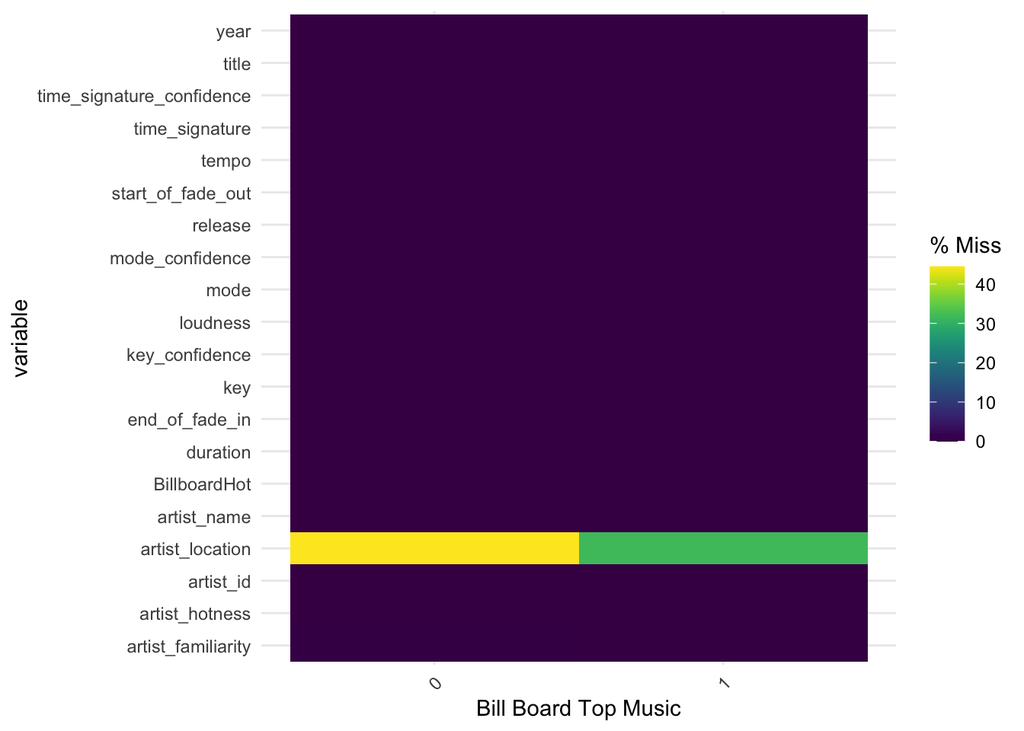

```r
t_bins <- bin(MusicDatasetMSD$BillboardHot, nbins = 2, method = "length") # Bin response variable
plot_dat <- cbind.data.frame(t_bins, MusicDatasetMSD[, feature_variables])
gg_miss_fct(x = plot_dat, fct = t_bins) +
  labs(x = "Bill Board Top Music")
```

#Looks like artist location has too many missing values, so I am going to drop artist location as well.

```r
MusicDatasetMSD <- MusicDatasetMSD[,-(4:4)]
```

```r
feature_variables <- names(MusicDatasetMSD)[]
summary(MusicDatasetMSD[,feature_variables])
```

```
##  artist_familiarity artist_hotness    artist_id         artist_name
##  Min.   :0.0000     Min.   :0.0000   Length:10001       Length:10001
##  1st Qu.:0.4676     1st Qu.:0.3253   Class :character   Class :character
##  Median :0.5637     Median :0.3808   Mode  :character   Mode  :character
##  Mean   :0.5655     Mean   :0.3856
##  3rd Qu.:0.6680     3rd Qu.:0.4539
##  Max.   :1.0000     Max.   :1.0825
##  NA's   :4
##     duration        end_of_fade_in         key         key_confidence
##  Min.   :   1.044   Min.   : 0.0000   Min.   : 0.000   Min.   :0.0000
##  1st Qu.: 176.039   1st Qu.: 0.0000   1st Qu.: 2.000   1st Qu.:0.2250
##  Median : 223.059   Median : 0.1990   Median : 5.000   Median :0.4690
##  Mean   : 238.512   Mean   : 0.7586   Mean   : 5.276   Mean   :0.4496
##  3rd Qu.: 276.375   3rd Qu.: 0.4210   3rd Qu.: 8.000   3rd Qu.:0.6590
##  Max.   :1819.768   Max.   :43.1190   Max.   :11.000   Max.   :1.0000
##
##     loudness            mode        mode_confidence    release
##  Min.   :-51.643   Min.   :0.0000   Min.   :0.0000   Length:10001
##  1st Qu.:-13.163   1st Qu.:0.0000   1st Qu.:0.3600   Class :character
##  Median : -9.380   Median :1.0000   Median :0.4870   Mode  :character
##  Mean   :-10.485   Mean   :0.6911   Mean   :0.4778
##  3rd Qu.: -6.531   3rd Qu.:1.0000   3rd Qu.:0.6060
##  Max.   :  0.566   Max.   :1.0000   Max.   :1.0000
##
##  start_of_fade_out      tempo        time_signature  time_signature_confidence
##  Min.   :   1.044   Min.   :  0.00   Min.   :0.000   Min.   :0.0000
##  1st Qu.: 168.856   1st Qu.: 96.97   1st Qu.:3.000   1st Qu.:0.0980
##  Median : 213.879   Median :120.16   Median :4.000   Median :0.5510
##  Mean   : 229.980   Mean   :122.92   Mean   :3.565   Mean   :0.5099
##  3rd Qu.: 266.292   3rd Qu.:144.02   3rd Qu.:4.000   3rd Qu.:0.8640
##  Max.   :1813.426   Max.   :262.83   Max.   :7.000   Max.   :1.0000
##
##     title                year         BillboardHot
##  Length:10001       Min.   :   0.0   Min.   :0.0000
##  Class :character   1st Qu.:   0.0   1st Qu.:0.0000
##  Mode  :character   Median :   0.0   Median :0.0000
##                     Mean   : 934.8   Mean   :0.1192
##                     3rd Qu.:2000.0   3rd Qu.:0.0000
##                     Max.   :2010.0   Max.   :1.0000
##
```

#The summary shows I am having 4 N/As with artist familiarity, but that is ok cause it is not a significant amount of missing values. For that, I decided to impute those 4 missing data for the artist familiarity variable

```r
set.seed(88888)
imputed_values <- mice( data = MusicDatasetMSD[, feature_variables], # Set dataset
                        m = 4, # Set number of multiple imputations
                        maxit = 40, # Set maximum number of iterations
                        method = "cart", # Set method
                        print = FALSE) # Set whether to print output or not
MusicDatasetMSD[,feature_variables] <- complete(imputed_values, 1)
```

```r
summary(MusicDatasetMSD[feature_variables])
```

```
##  artist_familiarity artist_hotness    artist_id         artist_name
##  Min.   :0.0000     Min.   :0.0000   Length:10001       Length:10001
##  1st Qu.:0.4676     1st Qu.:0.3253   Class :character   Class :character
##  Median :0.5636     Median :0.3808   Mode  :character   Mode  :character
##  Mean   :0.5654     Mean   :0.3856
##  3rd Qu.:0.6680     3rd Qu.:0.4539
##  Max.   :1.0000     Max.   :1.0825
##     duration        end_of_fade_in         key         key_confidence
##  Min.   :   1.044   Min.   : 0.0000   Min.   : 0.000   Min.   :0.0000
##  1st Qu.: 176.039   1st Qu.: 0.0000   1st Qu.: 2.000   1st Qu.:0.2250
##  Median : 223.059   Median : 0.1990   Median : 5.000   Median :0.4690
##  Mean   : 238.512   Mean   : 0.7586   Mean   : 5.276   Mean   :0.4496
##  3rd Qu.: 276.375   3rd Qu.: 0.4210   3rd Qu.: 8.000   3rd Qu.:0.6590
##  Max.   :1819.768   Max.   :43.1190   Max.   :11.000   Max.   :1.0000
##     loudness            mode        mode_confidence    release
##  Min.   :-51.643   Min.   :0.0000   Min.   :0.0000   Length:10001
##  1st Qu.:-13.163   1st Qu.:0.0000   1st Qu.:0.3600   Class :character
##  Median : -9.380   Median :1.0000   Median :0.4870   Mode  :character
##  Mean   :-10.485   Mean   :0.6911   Mean   :0.4778
##  3rd Qu.: -6.531   3rd Qu.:1.0000   3rd Qu.:0.6060
##  Max.   :  0.566   Max.   :1.0000   Max.   :1.0000
##  start_of_fade_out      tempo        time_signature  time_signature_confidence
##  Min.   :   1.044   Min.   :  0.00   Min.   :0.000   Min.   :0.0000
##  1st Qu.: 168.856   1st Qu.: 96.97   1st Qu.:3.000   1st Qu.:0.0980
##  Median : 213.879   Median :120.16   Median :4.000   Median :0.5510
##  Mean   : 229.980   Mean   :122.92   Mean   :3.565   Mean   :0.5099
##  3rd Qu.: 266.292   3rd Qu.:144.02   3rd Qu.:4.000   3rd Qu.:0.8640
##  Max.   :1813.426   Max.   :262.83   Max.   :7.000   Max.   :1.0000
##     title                year         BillboardHot
##  Length:10001       Min.   :   0.0   Min.   :0.0000
##  Class :character   1st Qu.:   0.0   1st Qu.:0.0000
##  Mode  :character   Median :   0.0   Median :0.0000
##                     Mean   : 934.8   Mean   :0.1192
##                     3rd Qu.:2000.0   3rd Qu.:0.0000
##                     Max.   :2010.0   Max.   :1.0000
```

#Now everything looks good. I have a clean set of data that is ready for further analysis.

#Time for some Viz. First I am going to plot artist familiarity agaisnt BillboardHot

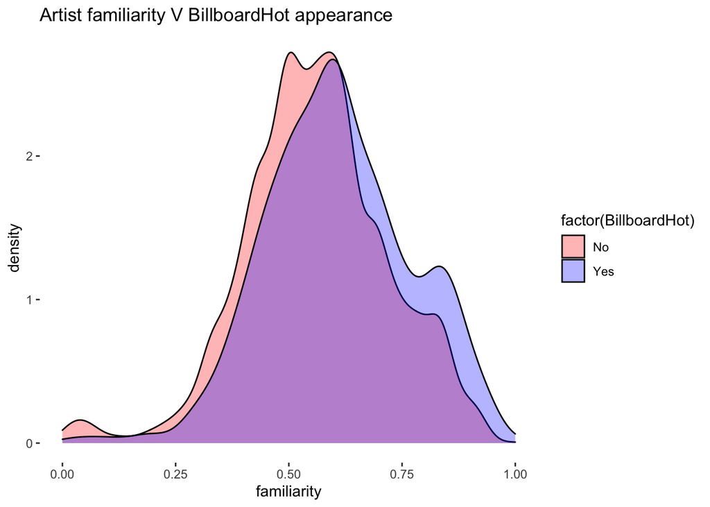

```r
g_1 <- ggplot(MusicDatasetMSD, aes(x = artist_familiarity, fill = factor(BillboardHot))) +
  geom_density(alpha = 0.3) + # Use geom_density to get density plot
  theme_bw() + # Set theme for plot
  theme(panel.grid.major = element_blank(), # Turn of the background grid
        panel.grid.minor = element_blank(),
        panel.border = element_blank(),
        panel.background = element_blank()) +
  labs(x = "familiarity", # Set p,lot labels
       title = "Artist familiarity V BillboardHot appearance") +
  scale_fill_manual(values = c("0" = "red", "1" = "blue"), # Manually set fill values
    labels = c("0" = "No", "1" = "Yes"))

g_1
```

#The graphs shows it actually makes a lot of sense between artist familiarity and billboardhot appearance, with higher familiarity having a higher chance of appearing on the BillboardHot while lower artist familiarity resulted in a lower chance of appearing on the BillboardHot.

#Next, I am checking on the relationship of plot artist hotness against BillboardHot

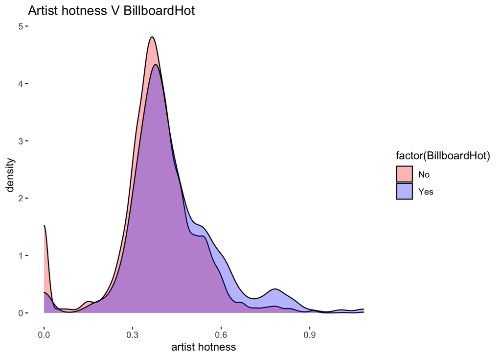

```r
g_2 <- ggplot(MusicDatasetMSD, aes(x = artist_hotness, fill = factor(BillboardHot))) +
  geom_density(alpha = 0.3)+
  theme_bw() +
  theme(panel.grid.major = element_blank(),
          panel.grid.minor = element_blank(),
          panel.border = element_blank(),
          panel.background = element_blank()) +
  labs(x = 'artist hotness',
       title = 'Artist hotness V BillboardHot') +
   scale_fill_manual(values = c("0" = "red", "1" = "blue"), # Manually set fill values
    labels = c("0" = "No", "1" = "Yes"))

g_2
```

#Checking out some other variables

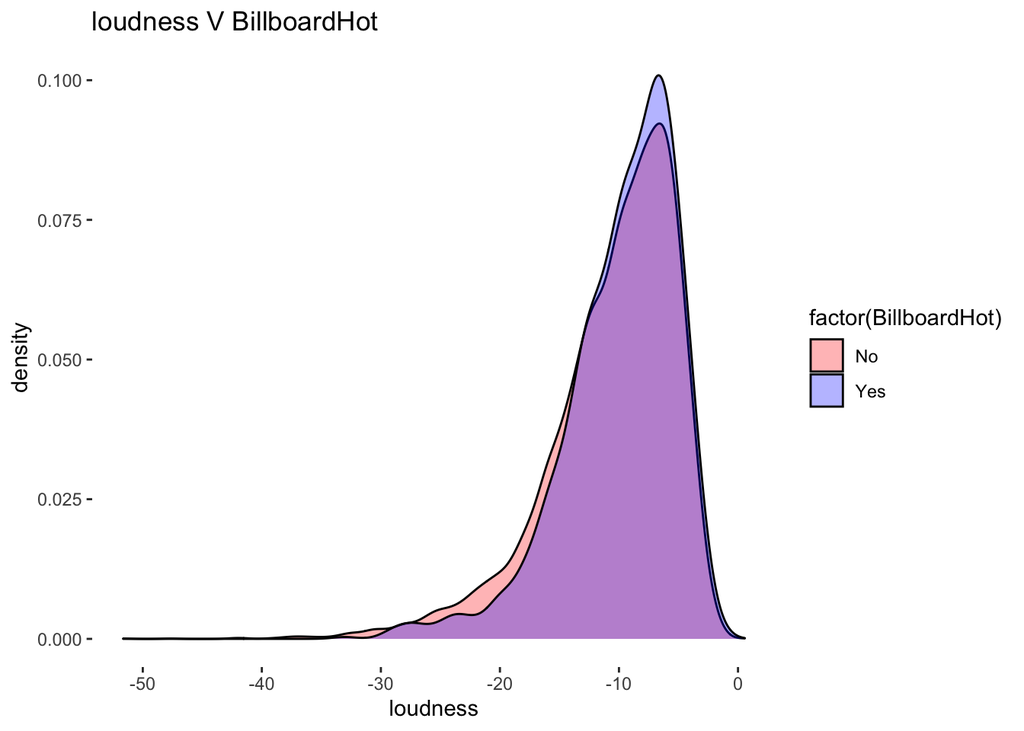

```r
ggplot(MusicDatasetMSD, aes(x = loudness, fill = factor(BillboardHot))) +
  geom_density(alpha = 0.3)+
  theme_bw() +
  theme(panel.grid.major = element_blank(),
          panel.grid.minor = element_blank(),
          panel.border = element_blank(),
          panel.background = element_blank()) +
  labs(x = 'loudness',
       title = 'loudness V BillboardHot') +
   scale_fill_manual(values = c("0" = "red", "1" = "blue"), # Manually set fill values
    labels = c("0" = "No", "1" = "Yes"))
```

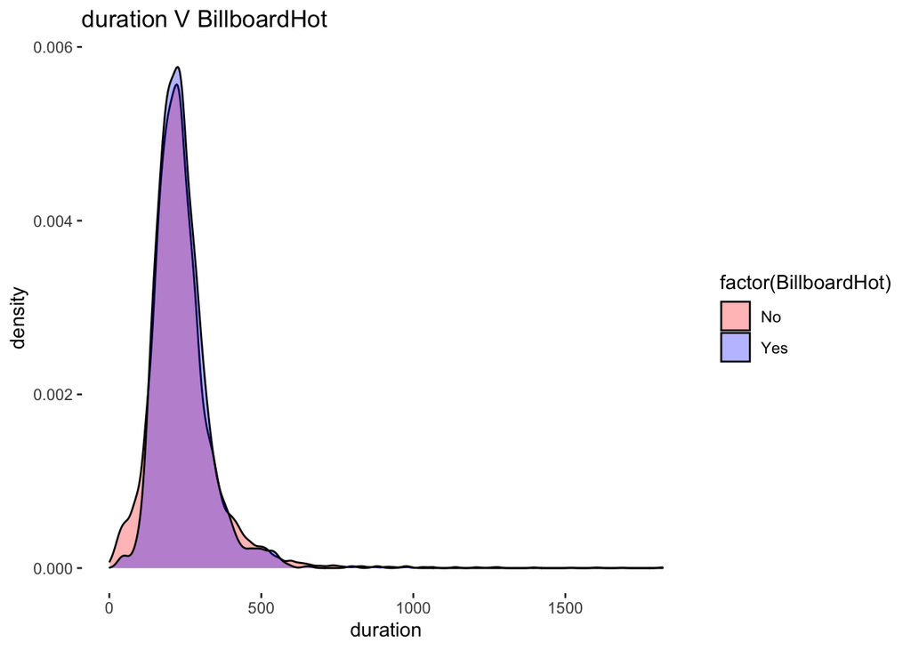

```r
ggplot(MusicDatasetMSD, aes(x = duration, fill = factor(BillboardHot))) +
  geom_density(alpha = 0.3)+
  theme_bw() +
  theme(panel.grid.major = element_blank(),
          panel.grid.minor = element_blank(),
          panel.border = element_blank(),
          panel.background = element_blank()) +
  labs(x = 'duration',
       title = 'duration V BillboardHot') +
   scale_fill_manual(values = c("0" = "red", "1" = "blue"), # Manually set fill values
    labels = c("0" = "No", "1" = "Yes"))
```

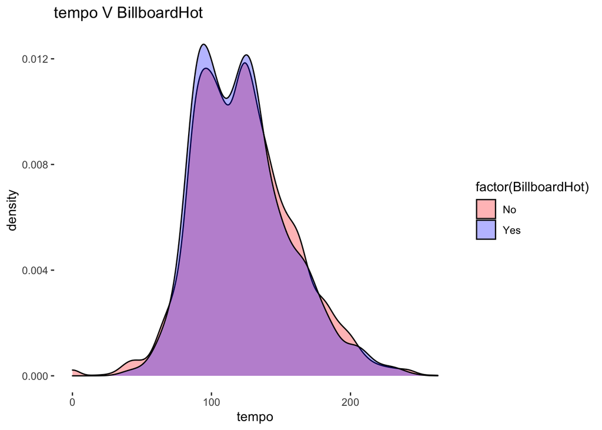

```r
ggplot(MusicDatasetMSD, aes(x = tempo, fill = factor(BillboardHot))) +
  geom_density(alpha = 0.3)+
  theme_bw() +
  theme(panel.grid.major = element_blank(),
          panel.grid.minor = element_blank(),
          panel.border = element_blank(),
          panel.background = element_blank()) +
  labs(x = 'tempo',
       title = 'tempo V BillboardHot') +
   scale_fill_manual(values = c("0" = "red", "1" = "blue"), # Manually set fill values
    labels = c("0" = "No", "1" = "Yes"))
```

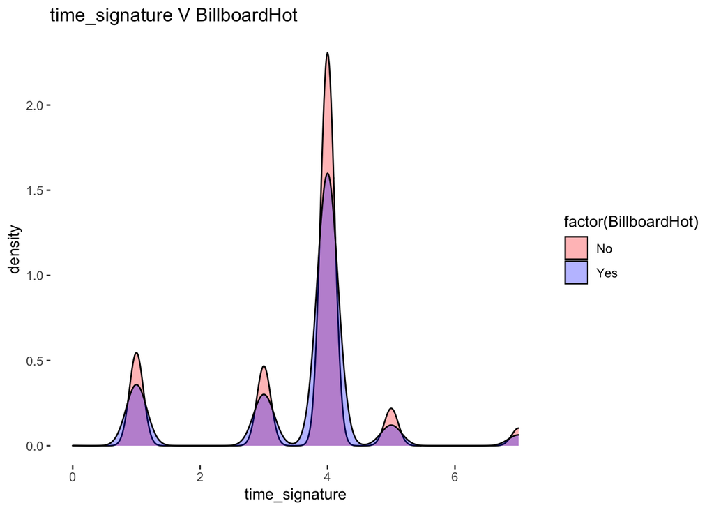

```r
ggplot(MusicDatasetMSD, aes(x = time_signature, fill = factor(BillboardHot))) +
  geom_density(alpha = 0.3)+
  theme_bw() +
  theme(panel.grid.major = element_blank(),
          panel.grid.minor = element_blank(),
          panel.border = element_blank(),
          panel.background = element_blank()) +
  labs(x = 'time_signature',
       title = 'time_signature V BillboardHot') +
   scale_fill_manual(values = c("0" = "red", "1" = "blue"), # Manually set fill values
    labels = c("0" = "No", "1" = "Yes"))
```

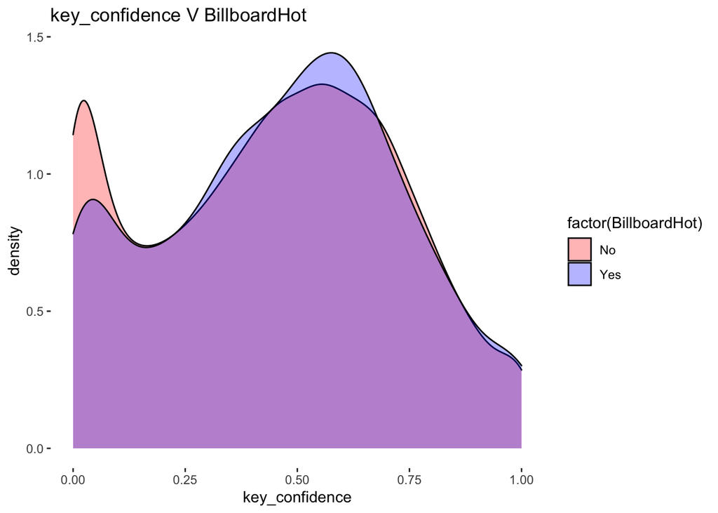

```r
ggplot(MusicDatasetMSD, aes(x = key_confidence, fill = factor(BillboardHot))) +
  geom_density(alpha = 0.3)+
  theme_bw() +
  theme(panel.grid.major = element_blank(),
          panel.grid.minor = element_blank(),
          panel.border = element_blank(),
          panel.background = element_blank()) +
  labs(x = 'key_confidence',
       title = 'key_confidence V BillboardHot') +
   scale_fill_manual(values = c("0" = "red", "1" = "blue"), # Manually set fill values
    labels = c("0" = "No", "1" = "Yes"))
```

#This concludes my initial finding for the short report. Artist familiarity and artist hotness do affect the chances of a song appearing in the BillboardHot 100 chart afterall.

#Now, I would like to run an XGboost model for this project. But before that, I would need to clean some data and prepare the train and test dataset.

```r
str(MusicDatasetMSD)
```

```
## tibble [10,001 × 19] (S3: tbl_df/tbl/data.frame)
##  $ artist_familiarity       : num [1:10001] 0.78 0.582 0.631 0.487 0.63 ...
##  $ artist_hotness           : num [1:10001] 0.574 0.402 0.417 0.343 0.454 ...
##  $ artist_id                : chr [1:10001] "ARMQHX71187B9890D3" "ARD7TVE1187B99BFB1" "ARMJAGH1187FB546F3" "ARKRRTF1187B9984DA" ...
##  $ artist_name              : chr [1:10001] "Mastodon" "Casual" "The Box Tops" "Sonora Santanera" ...
##  $ duration                 : num [1:10001] 280 219 148 177 233 ...
##  $ end_of_fade_in           : num [1:10001] 0.238 0.247 0.148 0.282 0 ...
##  $ key                      : num [1:10001] 5 1 6 8 0 2 5 1 4 4 ...
##  $ key_confidence           : num [1:10001] 0.555 0.736 0.169 0.643 0.751 0.092 0.635 0 0 0.717 ...
##  $ loudness                 : num [1:10001] -3.31 -11.2 -9.84 -9.69 -9.01 ...
##  $ mode                     : num [1:10001] 1 0 0 1 1 1 1 1 0 1 ...
##  $ mode_confidence          : num [1:10001] 0.5 0.636 0.43 0.565 0.749 0.371 0.557 0 0.16 0.652 ...
##  $ release                  : chr [1:10001] "Call of the Mastodon" "Fear Itself" "Dimensions" "Las Numero 1 De La Sonora Santanera" ...
##  $ start_of_fade_out        : num [1:10001] 276 219 138 172 217 ...
##  $ tempo                    : num [1:10001] 173.2 92.2 121.3 100.1 119.3 ...
##  $ time_signature           : num [1:10001] 5 4 4 1 4 4 3 1 3 4 ...
##  $ time_signature_confidence: num [1:10001] 0.12 0.778 0.384 0 0 0.562 0.454 0 0.408 0.487 ...
##  $ title                    : chr [1:10001] "Deep Sea Creature" "I Didn't Mean To" "Soul Deep" "Amor De Cabaret" ...
##  $ year                     : num [1:10001] 2001 0 1969 0 1982 ...
##  $ BillboardHot             : num [1:10001] 0 0 1 0 0 0 0 0 0 0 ...
```

```r
MusicDatasetMSD$artist_id <- as.numeric(MusicDatasetMSD$artist_id)
MusicDatasetMSD$artist_name <- as.numeric(MusicDatasetMSD$artist_name)
MusicDatasetMSD$release<- as.numeric(MusicDatasetMSD$release)
MusicDatasetMSD$title <- as.numeric(MusicDatasetMSD$title)
```

#Remove artist_id, artist_name, release, title cause not appropriate for numeric conversion

```r
MusicDatasetMSD <- MusicDatasetMSD[, -(3:4)]
```

```r
MusicDatasetMSD <- MusicDatasetMSD[, -(10:10)]
```

```r
MusicDatasetMSD <- MusicDatasetMSD[, -(14:14)]
```

```r
summary(MusicDatasetMSD)
```

```
##  artist_familiarity artist_hotness      duration        end_of_fade_in
##  Min.   :0.0000     Min.   :0.0000   Min.   :   1.044   Min.   : 0.0000
##  1st Qu.:0.4676     1st Qu.:0.3253   1st Qu.: 176.039   1st Qu.: 0.0000
##  Median :0.5636     Median :0.3808   Median : 223.059   Median : 0.1990
##  Mean   :0.5654     Mean   :0.3856   Mean   : 238.512   Mean   : 0.7586
##  3rd Qu.:0.6680     3rd Qu.:0.4539   3rd Qu.: 276.375   3rd Qu.: 0.4210
##  Max.   :1.0000     Max.   :1.0825   Max.   :1819.768   Max.   :43.1190
##       key         key_confidence      loudness            mode
##  Min.   : 0.000   Min.   :0.0000   Min.   :-51.643   Min.   :0.0000
##  1st Qu.: 2.000   1st Qu.:0.2250   1st Qu.:-13.163   1st Qu.:0.0000
##  Median : 5.000   Median :0.4690   Median : -9.380   Median :1.0000
##  Mean   : 5.276   Mean   :0.4496   Mean   :-10.485   Mean   :0.6911
##  3rd Qu.: 8.000   3rd Qu.:0.6590   3rd Qu.: -6.531   3rd Qu.:1.0000
##  Max.   :11.000   Max.   :1.0000   Max.   :  0.566   Max.   :1.0000
##  mode_confidence  start_of_fade_out      tempo        time_signature
##  Min.   :0.0000   Min.   :   1.044   Min.   :  0.00   Min.   :0.000
##  1st Qu.:0.3600   1st Qu.: 168.856   1st Qu.: 96.97   1st Qu.:3.000
##  Median :0.4870   Median : 213.879   Median :120.16   Median :4.000
##  Mean   :0.4778   Mean   : 229.980   Mean   :122.92   Mean   :3.565
##  3rd Qu.:0.6060   3rd Qu.: 266.292   3rd Qu.:144.02   3rd Qu.:4.000
##  Max.   :1.0000   Max.   :1813.426   Max.   :262.83   Max.   :7.000
##  time_signature_confidence      year         BillboardHot
##  Min.   :0.0000            Min.   :   0.0   Min.   :0.0000
##  1st Qu.:0.0980            1st Qu.:   0.0   1st Qu.:0.0000
##  Median :0.5510            Median :   0.0   Median :0.0000
##  Mean   :0.5099            Mean   : 934.8   Mean   :0.1192
##  3rd Qu.:0.8640            3rd Qu.:2000.0   3rd Qu.:0.0000
##  Max.   :1.0000            Max.   :2010.0   Max.   :1.0000
```

```r
str(MusicDatasetMSD)
```

```
## tibble [10,001 × 15] (S3: tbl_df/tbl/data.frame)
##  $ artist_familiarity       : num [1:10001] 0.78 0.582 0.631 0.487 0.63 ...
##  $ artist_hotness           : num [1:10001] 0.574 0.402 0.417 0.343 0.454 ...
##  $ duration                 : num [1:10001] 280 219 148 177 233 ...
##  $ end_of_fade_in           : num [1:10001] 0.238 0.247 0.148 0.282 0 ...
##  $ key                      : num [1:10001] 5 1 6 8 0 2 5 1 4 4 ...
##  $ key_confidence           : num [1:10001] 0.555 0.736 0.169 0.643 0.751 0.092 0.635 0 0 0.717 ...
##  $ loudness                 : num [1:10001] -3.31 -11.2 -9.84 -9.69 -9.01 ...
##  $ mode                     : num [1:10001] 1 0 0 1 1 1 1 1 0 1 ...
##  $ mode_confidence          : num [1:10001] 0.5 0.636 0.43 0.565 0.749 0.371 0.557 0 0.16 0.652 ...
##  $ start_of_fade_out        : num [1:10001] 276 219 138 172 217 ...
##  $ tempo                    : num [1:10001] 173.2 92.2 121.3 100.1 119.3 ...
##  $ time_signature           : num [1:10001] 5 4 4 1 4 4 3 1 3 4 ...
##  $ time_signature_confidence: num [1:10001] 0.12 0.778 0.384 0 0 0.562 0.454 0 0.408 0.487 ...
##  $ year                     : num [1:10001] 2001 0 1969 0 1982 ...
##  $ BillboardHot             : num [1:10001] 0 0 1 0 0 0 0 0 0 0 ...
```

```r
library(xgboost) # Load XGBoost
library(caret) # Load Caret
```

```r
library(OptimalCutpoints) # Load optimal cutpoints
library(ggplot2) # Load ggplot2
library(pROC) # Load proc
library(SHAPforxgboost) # Load shap for XGBoost
```

```r
library(splitstackshape)
set.seed(123456) # Set seed

#Perform stratified sampling
 split_dat <- stratified(MusicDatasetMSD, # Set dataset
                         group = "BillboardHot", # Set variables to use for stratification
                         size = 0.2,  # Set size of test set
                         bothSets = TRUE ) # Return both training and test sets
 # Extract train data
 train_dat <- split_dat[[2]]
 # Extract test data
 test_dat <- split_dat[[1]]

# Check size
nrow(train_dat)
```

```
## [1] 8001
```

```r
nrow(test_dat)
```

```
## [1] 2000
```

```r
str(train_dat)
```

```
## Classes 'data.table' and 'data.frame':   8001 obs. of  15 variables:
##  $ artist_familiarity       : num  0.78 0.582 0.631 0.63 0.651 ...
##  $ artist_hotness           : num  0.574 0.402 0.417 0.454 0.402 ...
##  $ duration                 : num  280 219 148 233 210 ...
##  $ end_of_fade_in           : num  0.238 0.247 0.148 0 0.066 ...
##  $ key                      : num  5 1 6 0 2 1 4 4 7 5 ...
##  $ key_confidence           : num  0.555 0.736 0.169 0.751 0.092 0 0 0.717 0.053 0.354 ...
##  $ loudness                 : num  -3.31 -11.2 -9.84 -9.01 -4.5 ...
##  $ mode                     : num  1 0 0 1 1 1 0 1 0 0 ...
##  $ mode_confidence          : num  0.5 0.636 0.43 0.749 0.371 0 0.16 0.652 0.473 0.485 ...
##  $ start_of_fade_out        : num  276 219 138 217 199 ...
##  $ tempo                    : num  173.2 92.2 121.3 119.3 129.7 ...
##  $ time_signature           : num  5 4 4 4 4 1 3 4 4 1 ...
##  $ time_signature_confidence: num  0.12 0.778 0.384 0 0.562 0 0.408 0.487 0.878 0 ...
##  $ year                     : num  2001 0 1969 1982 2007 ...
##  $ BillboardHot             : num  0 0 1 0 0 0 0 0 0 1 ...
##  - attr(*, ".internal.selfref")=<externalptr>
```

```r
sum(is.na(train_dat))
```

```
## [1] 0
```

```r
sum(is.na(test_dat))
```

```
## [1] 0
```

```r
summary(as.factor(train_dat$BillboardHot))
```

```
##    0    1
## 7047  954
```

```r
summary(as.factor(test_dat$BillboardHot))
```

```
##    0    1
## 1762  238
```

```r
# Create training matrix
dtrain <- xgb.DMatrix(data = as.matrix(train_dat[, 1:14]), label = as.numeric(train_dat$BillboardHot))
# Create test matrix
dtest <- xgb.DMatrix(data = as.matrix(test_dat[, 1:14]), label = as.numeric(test_dat$BillboardHot))
```

#Now that I have both train and test dataset, I would like to train the XGBoost model

```r
set.seed(88888)
bst_1 <- xgboost(data = dtrain, # Set training data

               nrounds = 100, # Set number of rounds

               verbose = 1, # 1 - Prints out fit
                print_every_n = 20, # Prints out result every 20th iteration

               objective = "binary:logistic", # Set objective
               eval_metric = "auc",
               eval_metric = "error") # Set evaluation metric to use
```

#Now I would like to predict with XGboost

```r
boost_preds <- predict(bst_1, dtrain) # Create predictions for xgboost model
# Join predictions and actual
pred_dat <- cbind.data.frame(boost_preds , train_dat$BillboardHot)
names(pred_dat) <- c("predictions", "response")
oc<- optimal.cutpoints(X = "predictions",
                       status = "response",
                       tag.healthy = 0,
                       data = pred_dat,
                       methods = "MaxEfficiency")

boost_preds_1 <- predict(bst_1, dtest) # Create predictions for xgboost model

pred_dat <- cbind.data.frame(boost_preds_1 , test_dat$BillboardHot)#
# Convert predictions to classes, using optimal cut-off
boost_pred_class <- rep(0, length(boost_preds_1))
boost_pred_class[boost_preds_1 >= oc$MaxEfficiency$Global$optimal.cutoff$cutoff[1]] <- 1


t <- table(boost_pred_class, test_dat$BillboardHot) # Create table
confusionMatrix(t, positive = "1") # Produce confusion matrix
```

```
## Confusion Matrix and Statistics
##
##
## boost_pred_class    0    1
##                0 1642  203
##                1  120   35
##
##                Accuracy : 0.8385
##                  95% CI : (0.8216, 0.8544)
##     No Information Rate : 0.881
##     P-Value [Acc > NIR] : 1
##
##                   Kappa : 0.093
##
##  Mcnemar's Test P-Value : 5.052e-06
##
##             Sensitivity : 0.1471
##             Specificity : 0.9319
##          Pos Pred Value : 0.2258
##          Neg Pred Value : 0.8900
##              Prevalence : 0.1190
##          Detection Rate : 0.0175
##    Detection Prevalence : 0.0775
##       Balanced Accuracy : 0.5395
##
##        'Positive' Class : 1
##
```

#The first predicted result shows an accuracy rate here.

#Now I would like to tune my model to see how it fares. I am doing it with cross validation inside xgboost.

```r
# Use xgb.cv to run cross-validation inside xgboost
set.seed(888888)
bst <- xgb.cv(data = dtrain, # Set training data

              nfold = 5, # Use 5 fold cross-validation

               eta = 0.1, # Set learning rate

               nrounds = 1000, # Set number of rounds
               early_stopping_rounds = 50, # Set number of rounds to stop at if there is no improvement

               verbose = 1, # 1 - Prints out fit
               nthread = 1, # Set number of parallel threads
               print_every_n = 20, # Prints out result every 20th iteration

               objective = "binary:logistic", # Set objective
               eval_metric = "auc",
               eval_metric = "error") # Set evaluation metric to use
```

```
## Multiple eval metrics are present. Will use test_error for early stopping.
## Will train until test_error hasn't improved in 50 rounds.
##
## Stopping. Best iteration:
```

#Next, I am tuning the max depth and min child weight

```r
max_depth_vals <- c(3, 5, 7, 10, 15) # Create vector of max depth values
min_child_weight <- c(1,3,5,7, 10, 15) # Create vector of min child values

# Expand grid of parameter values
cv_params <- expand.grid(max_depth_vals, min_child_weight)
names(cv_params) <- c("max_depth", "min_child_weight")
# Create results vector
auc_vec <- error_vec <- rep(NA, nrow(cv_params))
# Loop through results
for(i in 1:nrow(cv_params)){
  set.seed(888888)
  bst_tune <- xgb.cv(data = dtrain, # Set training data

              nfold = 5, # Use 5 fold cross-validation

              eta = 0.1, # Set learning rate
              max.depth = cv_params$max_depth[i], # Set max depth
              min_child_weight = cv_params$min_child_weight[i], # Set minimum number of samples in node to split


              nrounds = 100, # Set number of rounds
              early_stopping_rounds = 20, # Set number of rounds to stop at if there is no improvement

              verbose = 1, # 1 - Prints out fit
              nthread = 1, # Set number of parallel threads
              print_every_n = 20, # Prints out result every 20th iteration

              objective = "binary:logistic", # Set objective
              eval_metric = "auc", # Set evaluation metric to use
              eval_metric = "error") # Set evaluation metric to use
  auc_vec[i] <- bst_tune$evaluation_log$test_auc_mean[bst_tune$best_ntreelimit]
  error_vec[i] <- bst_tune$evaluation_log$test_error_mean[bst_tune$best_ntreelimit]

}
```

[output not shown]

[output cut: 92 more lines]

```
##
## Multiple eval metrics are present. Will use test_error for early stopping.
## Will train until test_error hasn't improved in 20 rounds.
##
## Stopping. Best iteration:
##
## Multiple eval metrics are present. Will use test_error for early stopping.
## Will train until test_error hasn't improved in 20 rounds.
##
## Stopping. Best iteration:
##
## Multiple eval metrics are present. Will use test_error for early stopping.
## Will train until test_error hasn't improved in 20 rounds.
##
## Stopping. Best iteration:
```

#After getting the results, I am joinign them back to the dataset

```r
res_db <- cbind.data.frame(cv_params, auc_vec, error_vec)
names(res_db)[3:4] <- c("auc", "error")
```

#plotting a graph to see how it looks like. But before that I need to convert the max depth and min chld error to factor variables.

```r
res_db$max_depth <- as.factor(res_db$max_depth)
res_db$min_child_weight <- as.factor(res_db$min_child_weight)
```

#OK now thre variables looks good and are ready for plotting.

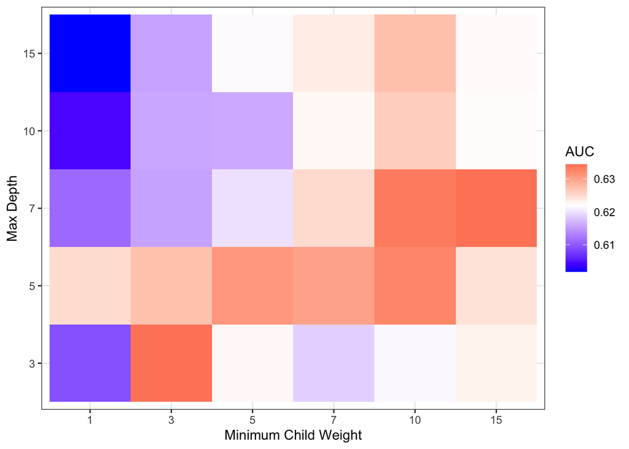

```r
g_3 <- ggplot(res_db, aes(y = max_depth, x = min_child_weight, fill = auc)) + # set aesthetics
  geom_tile() + # Use geom_tile for heatmap
  theme_bw() + # Set theme
  scale_fill_gradient2(low = "blue", # Choose low color
    mid = "white", # Choose mid color
    high = "red", # Choose high color
    midpoint =mean(res_db$auc), # Choose mid point
    space = "Lab",
    na.value ="grey", # Choose NA value
    guide = "colourbar", # Set color bar
    aesthetics = "fill") + # Select aesthetics to apply
  labs(x = "Minimum Child Weight", y = "Max Depth", fill = "AUC") # Set labels
g_3 # Generate plot
```

#printing error heat map

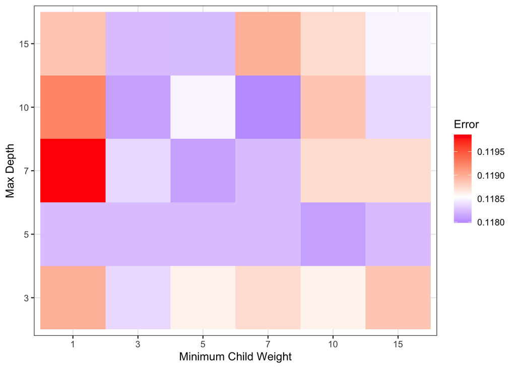

```r
# print error heatmap
g_4 <- ggplot(res_db, aes(y = max_depth, x = min_child_weight, fill = error)) + # set aesthetics
  geom_tile() + # Use geom_tile for heatmap
  theme_bw() + # Set theme
  scale_fill_gradient2(low = "blue", # Choose low color
    mid = "white", # Choose mid color
    high = "red", # Choose high color
    midpoint =mean(res_db$error), # Choose mid point
    space = "Lab",
    na.value ="grey", # Choose NA value
    guide = "colourbar", # Set color bar
    aesthetics = "fill") + # Select aesthetics to apply
  labs(x = "Minimum Child Weight", y = "Max Depth", fill = "Error") # Set labels
g_4 # Generate plot
```

```r
res_db # Print results
```

```
##    max_depth min_child_weight       auc     error
## 1          3                1 0.6091260 0.1189852
## 2          5                1 0.6250208 0.1182358
## 3          7                1 0.6112988 0.1198602
## 4         10                1 0.6046100 0.1192356
## 5         15                1 0.6018406 0.1188600
## 6          3                3 0.6342440 0.1183602
## 7          5                3 0.6272422 0.1182356
## 8          7                3 0.6155768 0.1183604
## 9         10                3 0.6159422 0.1181106
## 10        15                3 0.6156994 0.1182354
## 11         3                5 0.6225814 0.1186100
## 12         5                5 0.6309162 0.1182352
## 13         7                5 0.6198994 0.1181104
## 14        10                5 0.6161554 0.1184852
```

[output cut: 16 more lines]

#Now I have a better model, I would like to improve it further. So I am tuning the gamma to determine the minimum loss reduction that is needed to add another partition in a node.

```r
gamma_vals <- c(0, 0.05, 0.1, 0.15, 0.2) # Create vector of gamma values

# Be Careful - This can take a very long time to run
set.seed(888888)
auc_vec <- error_vec <- rep(NA, length(gamma_vals))
for(i in 1:length(gamma_vals)){
  bst_tune <- xgb.cv(data = dtrain, # Set training data

              nfold = 5, # Use 5 fold cross-validation

              eta = 0.1, # Set learning rate
              max.depth = 5, # Set max depth
              min_child_weight = 10, # Set minimum number of samples in node to split
              gamma = gamma_vals[i], # Set minimum loss reduction for split



              nrounds = 100, # Set number of rounds
              early_stopping_rounds = 20, # Set number of rounds to stop at if there is no improvement

              verbose = 1, # 1 - Prints out fit
              nthread = 1, # Set number of parallel threads
              print_every_n = 20, # Prints out result every 20th iteration

              objective = "binary:logistic", # Set objective
              eval_metric = "auc", # Set evaluation metric to use
              eval_metric = "error") # Set evaluation metric to use
  auc_vec[i] <- bst_tune$evaluation_log$test_auc_mean[bst_tune$best_ntreelimit]
  error_vec[i] <- bst_tune$evaluation_log$test_error_mean[bst_tune$best_ntreelimit]

}
```

```
## Multiple eval metrics are present. Will use test_error for early stopping.
## Will train until test_error hasn't improved in 20 rounds.
##
## Stopping. Best iteration:
##
## Multiple eval metrics are present. Will use test_error for early stopping.
## Will train until test_error hasn't improved in 20 rounds.
##
## Stopping. Best iteration:
##
## Multiple eval metrics are present. Will use test_error for early stopping.
## Will train until test_error hasn't improved in 20 rounds.
##
## Stopping. Best iteration:
##
## Multiple eval metrics are present. Will use test_error for early stopping.
## Will train until test_error hasn't improved in 20 rounds.
##
## Stopping. Best iteration:
##
## Multiple eval metrics are present. Will use test_error for early stopping.
## Will train until test_error hasn't improved in 20 rounds.
##
## Stopping. Best iteration:
```

#See gamma results

```r
# Join gamma to values
cbind.data.frame(gamma_vals, auc_vec, error_vec)
```

```
##   gamma_vals   auc_vec error_vec
## 1       0.00 0.6325760 0.1181100
## 2       0.05 0.6279274 0.1187366
## 3       0.10 0.6306724 0.1184856
## 4       0.15 0.6289248 0.1191114
## 5       0.20 0.6280532 0.1189854
```

#Great! AUC is the highest and error the lowest when GAMMA is at 0. And for that I will use GAMMA as 0 going forward. But will try to increaease the number of rounds to 1000 this time just to make it more useful to the model.

```r
# Use xgb.cv to run cross-validation inside xgboost
set.seed(888888)
bst <- xgb.cv(data = dtrain, # Set training data

              nfold = 5, # Use 5 fold cross-validation

              eta = 0.1, # Set learning rate
              max.depth = 5, # Set max depth
              min_child_weight = 10, # Set minimum number of samples in node to split
              gamma = 0, # Set minimum loss reduction for split


              nrounds = 1000, # Set number of rounds
              early_stopping_rounds = 50, # Set number of rounds to stop at if there is no improvement

              verbose = 1, # 1 - Prints out fit
              nthread = 1, # Set number of parallel threads
              print_every_n = 20, # Prints out result every 20th iteration

              objective = "binary:logistic", # Set objective
              eval_metric = "auc",
              eval_metric = "error") # Set evaluation metric to use
```

```
## Multiple eval metrics are present. Will use test_error for early stopping.
## Will train until test_error hasn't improved in 50 rounds.
##
## Stopping. Best iteration:
```

#OK. Now I would like to tune the subsample and col_sample_by_tree parameters.

```r
# Be Careful - This can take a very long time to run
subsample <- c(0.6, 0.7, 0.8, 0.9, 1) # Create vector of subsample values
colsample_by_tree <- c(0.6, 0.7, 0.8, 0.9, 1) # Create vector of col sample values

# Expand grid of tuning parameters
cv_params <- expand.grid(subsample, colsample_by_tree)
names(cv_params) <- c("subsample", "colsample_by_tree")
# Create vectors to store results
auc_vec <- error_vec <- rep(NA, nrow(cv_params))
# Loop through parameter values
for(i in 1:nrow(cv_params)){
  set.seed(888888)
  bst_tune <- xgb.cv(data = dtrain, # Set training data

              nfold = 5, # Use 5 fold cross-validation

              eta = 0.1, # Set learning rate
              max.depth = 5, # Set max depth
              min_child_weight = 10, # Set minimum number of samples in node to split
              gamma = 0, # Set minimum loss reduction for split
              subsample = cv_params$subsample[i], # Set proportion of training data to use in tree
              colsample_bytree = cv_params$colsample_by_tree[i], # Set number of variables to use in each tree

              nrounds = 150, # Set number of rounds
              early_stopping_rounds = 20, # Set number of rounds to stop at if there is no improvement

              verbose = 1, # 1 - Prints out fit
              nthread = 1, # Set number of parallel threads
              print_every_n = 20, # Prints out result every 20th iteration

              objective = "binary:logistic", # Set objective
              eval_metric = "auc", # Set evaluation metric to use
              eval_metric = "error") # Set evaluation metric to use
  auc_vec[i] <- bst_tune$evaluation_log$test_auc_mean[bst_tune$best_ntreelimit]
  error_vec[i] <- bst_tune$evaluation_log$test_error_mean[bst_tune$best_ntreelimit]

}
```

[output not shown]

[output cut: 69 more lines]

[output not shown]

#TIme to see how they look

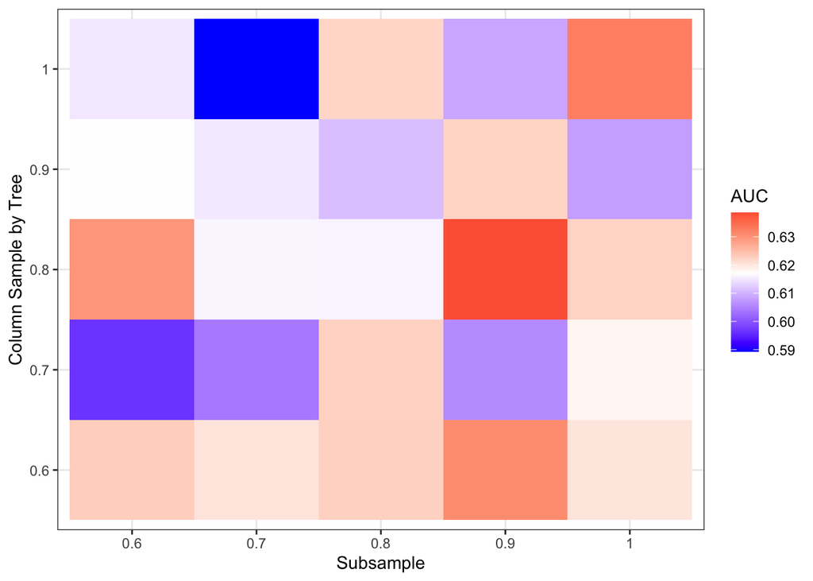

```r
res_db <- cbind.data.frame(cv_params, auc_vec, error_vec)
names(res_db)[3:4] <- c("auc", "error")
res_db$subsample <- as.factor(res_db$subsample) # Convert tree number to factor for plotting
res_db$colsample_by_tree <- as.factor(res_db$colsample_by_tree) # Convert node size to factor for plotting
g_5 <- ggplot(res_db, aes(y = colsample_by_tree, x = subsample, fill = auc)) + # set aesthetics
  geom_tile() + # Use geom_tile for heatmap
  theme_bw() + # Set theme
  scale_fill_gradient2(low = "blue", # Choose low color
    mid = "white", # Choose mid color
    high = "red", # Choose high color
    midpoint =mean(res_db$auc), # Choose mid point
    space = "Lab",
    na.value ="grey", # Choose NA value
    guide = "colourbar", # Set color bar
    aesthetics = "fill") + # Select aesthetics to apply
  labs(x = "Subsample", y = "Column Sample by Tree", fill = "AUC") # Set labels
g_5 # Generate plot
```

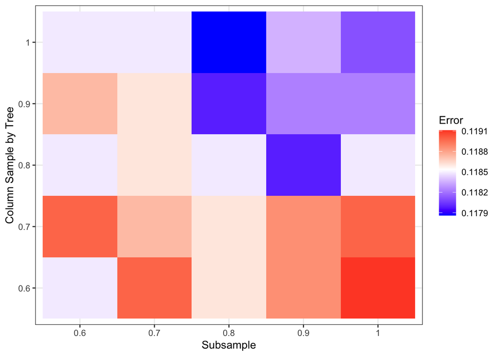

```r
g_6 <- ggplot(res_db, aes(y = colsample_by_tree, x = subsample, fill = error)) + # set aesthetics
  geom_tile() + # Use geom_tile for heatmap
  theme_bw() + # Set theme
  scale_fill_gradient2(low = "blue", # Choose low color
    mid = "white", # Choose mid color
    high = "red", # Choose high color
    midpoint =mean(res_db$error), # Choose mid point
    space = "Lab",
    na.value ="grey", # Choose NA value
    guide = "colourbar", # Set color bar
    aesthetics = "fill") + # Select aesthetics to apply
  labs(x = "Subsample", y = "Column Sample by Tree", fill = "Error") # Set labels
g_6 # Generate plot
```

```r
res_db
```

```
##    subsample colsample_by_tree       auc     error
## 1        0.6               0.6 0.6230182 0.1184850
## 2        0.7               0.6 0.6203656 0.1189848
## 3        0.8               0.6 0.6226522 0.1186100
## 4        0.9               0.6 0.6309346 0.1188600
## 5          1               0.6 0.6202308 0.1191100
## 6        0.6               0.7 0.5964864 0.1189850
## 7        0.7               0.7 0.6038870 0.1187350
## 8        0.8               0.7 0.6225306 0.1186100
## 9        0.9               0.7 0.6059220 0.1188598
## 10         1               0.7 0.6183088 0.1189850
## 11       0.6               0.8 0.6298054 0.1184850
## 12       0.7               0.8 0.6161490 0.1186098
## 13       0.8               0.8 0.6160418 0.1184850
## 14       0.9               0.8 0.6385322 0.1179850
## 15         1               0.8 0.6222280 0.1184850
## 16       0.6               0.9 0.6172472 0.1187350
## 17       0.7               0.9 0.6150994 0.1186098
## 18       0.8               0.9 0.6111118 0.1179850
## 19       0.9               0.9 0.6222534 0.1182352
## 20         1               0.9 0.6078444 0.1182350
## 21       0.6                 1 0.6150402 0.1184850
## 22       0.7                 1 0.5892846 0.1184850
## 23       0.8                 1 0.6221620 0.1178598
## 24       0.9                 1 0.6086680 0.1183602
## 25         1                 1 0.6325760 0.1181100
```

#OK, now on to ETA tuning. #ETA to 0.3

```r
# Use xgb.cv to run cross-validation inside xgboost
set.seed(888888)
bst_mod_1 <- xgb.cv(data = dtrain, # Set training data

              nfold = 5, # Use 5 fold cross-validation

              eta = 0.3, # Set learning rate
              max.depth = 5, # Set max depth
              min_child_weight = 10, # Set minimum number of samples in node to split
              gamma = 0, # Set minimum loss reduction for split
              subsample = 0.9, # Set proportion of training data to use in tree
              colsample_bytree =  0.8, # Set number of variables to use in each tree

              nrounds = 1000, # Set number of rounds
              early_stopping_rounds = 20, # Set number of rounds to stop at if there is no improvement

              verbose = 1, # 1 - Prints out fit
              nthread = 1, # Set number of parallel threads
              print_every_n = 20, # Prints out result every 20th iteration

              objective = "binary:logistic", # Set objective
              eval_metric = "auc",
              eval_metric = "error") # Set evaluation metric to use
```

```
## Multiple eval metrics are present. Will use test_error for early stopping.
## Will train until test_error hasn't improved in 20 rounds.
##
## Stopping. Best iteration:
```

#ETA to 0.1

```r
# Use xgb.cv to run cross-validation inside xgboost
set.seed(888888)
bst_mod_2 <- xgb.cv(data = dtrain, # Set training data

              nfold = 5, # Use 5 fold cross-validation

              eta = 0.1, # Set learning rate
              max.depth = 5, # Set max depth
              min_child_weight = 10, # Set minimum number of samples in node to split
              gamma = 0, # Set minimum loss reduction for split
              subsample = 0.9, # Set proportion of training data to use in tree
              colsample_bytree =  0.8, # Set number of variables to use in each tree

              nrounds = 1000, # Set number of rounds
              early_stopping_rounds = 20, # Set number of rounds to stop at if there is no improvement

              verbose = 1, # 1 - Prints out fit
              nthread = 1, # Set number of parallel threads
              print_every_n = 20, # Prints out result every 20th iteration

              objective = "binary:logistic", # Set objective
              eval_metric = "auc",
              eval_metric = "error") # Set evaluation metric to use
```

```
## Multiple eval metrics are present. Will use test_error for early stopping.
## Will train until test_error hasn't improved in 20 rounds.
##
## Stopping. Best iteration:
```

#ETA to 0.05

```r
# Use xgb.cv to run cross-validation inside xgboost
set.seed(888888)
bst_mod_3 <- xgb.cv(data = dtrain, # Set training data

              nfold = 5, # Use 5 fold cross-validation

              eta = 0.05, # Set learning rate
              max.depth = 5, # Set max depth
              min_child_weight = 10, # Set minimum number of samples in node to split
              gamma = 0, # Set minimum loss reduction for split
              subsample = 0.9, # Set proportion of training data to use in tree
              colsample_bytree =  0.8, # Set number of variables to use in each tree

              nrounds = 1000, # Set number of rounds
              early_stopping_rounds = 20, # Set number of rounds to stop at if there is no improvement

              verbose = 1, # 1 - Prints out fit
              nthread = 1, # Set number of parallel threads
              print_every_n = 20, # Prints out result every 20th iteration

              objective = "binary:logistic", # Set objective
              eval_metric = "auc",
              eval_metric = "error") # Set evaluation metric to use
```

```
## Multiple eval metrics are present. Will use test_error for early stopping.
## Will train until test_error hasn't improved in 20 rounds.
##
## Stopping. Best iteration:
```

#ETA to 0.01

```r
# Use xgb.cv to run cross-validation inside xgboost
set.seed(888888)
bst_mod_4 <- xgb.cv(data = dtrain, # Set training data

              nfold = 5, # Use 5 fold cross-validation

              eta = 0.01, # Set learning rate
              max.depth = 5, # Set max depth
              min_child_weight = 10, # Set minimum number of samples in node to split
              gamma = 0, # Set minimum loss reduction for split
              subsample = 0.9, # Set proportion of training data to use in tree
              colsample_bytree =  0.8, # Set number of variables to use in each tree

              nrounds = 1000, # Set number of rounds
              early_stopping_rounds = 20, # Set number of rounds to stop at if there is no improvement

              verbose = 1, # 1 - Prints out fit
              nthread = 1, # Set number of parallel threads
              print_every_n = 20, # Prints out result every 20th iteration

              objective = "binary:logistic", # Set objective
              eval_metric = "auc",
              eval_metric = "error") # Set evaluation metric to use
```

```
## Multiple eval metrics are present. Will use test_error for early stopping.
## Will train until test_error hasn't improved in 20 rounds.
##
## Stopping. Best iteration:
```

#ETA to 0.005

```r
# Use xgb.cv to run cross-validation inside xgboost
set.seed(888888)
bst_mod_5 <- xgb.cv(data = dtrain, # Set training data

              nfold = 5, # Use 5 fold cross-validation

              eta = 0.005, # Set learning rate
              max.depth = 5, # Set max depth
              min_child_weight = 10, # Set minimum number of samples in node to split
              gamma = 0, # Set minimum loss reduction for split
              subsample = 0.9, # Set proportion of training data to use in tree
              colsample_bytree =  0.8, # Set number of variables to use in each tree

              nrounds = 1000, # Set number of rounds
              early_stopping_rounds = 20, # Set number of rounds to stop at if there is no improvement

              verbose = 1, # 1 - Prints out fit
              nthread = 1, # Set number of parallel threads
              print_every_n = 20, # Prints out result every 20th iteration

              objective = "binary:logistic", # Set objective
              eval_metric = "auc",
              eval_metric = "error") # Set evaluation metric to use
```

```
## Multiple eval metrics are present. Will use test_error for early stopping.
## Will train until test_error hasn't improved in 20 rounds.
##
## Stopping. Best iteration:
```

#now that I have many those different ETAs, I would like to plot the error rates

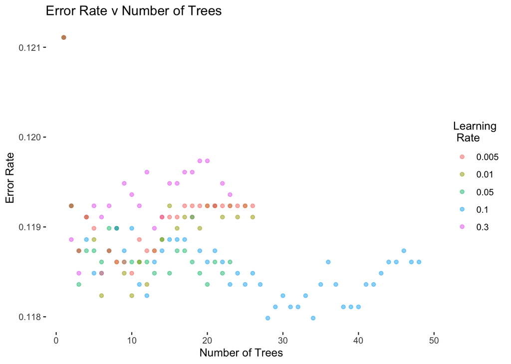

```r
# Extract results for model with eta = 0.3
pd1 <- cbind.data.frame(bst_mod_1$evaluation_log[,c("iter", "test_error_mean")], rep(0.3, nrow(bst_mod_1$evaluation_log)))
names(pd1)[3] <- "eta"
# Extract results for model with eta = 0.1
pd2 <- cbind.data.frame(bst_mod_2$evaluation_log[,c("iter", "test_error_mean")], rep(0.1, nrow(bst_mod_2$evaluation_log)))
names(pd2)[3] <- "eta"
# Extract results for model with eta = 0.05
pd3 <- cbind.data.frame(bst_mod_3$evaluation_log[,c("iter", "test_error_mean")], rep(0.05, nrow(bst_mod_3$evaluation_log)))
names(pd3)[3] <- "eta"
# Extract results for model with eta = 0.01
pd4 <- cbind.data.frame(bst_mod_4$evaluation_log[,c("iter", "test_error_mean")], rep(0.01, nrow(bst_mod_4$evaluation_log)))
names(pd4)[3] <- "eta"
# Extract results for model with eta = 0.005
pd5 <- cbind.data.frame(bst_mod_5$evaluation_log[,c("iter", "test_error_mean")], rep(0.005, nrow(bst_mod_5$evaluation_log)))
names(pd5)[3] <- "eta"
# Join datasets
plot_data <- rbind.data.frame(pd1, pd2, pd3, pd4, pd5)
# Converty ETA to factor
plot_data$eta <- as.factor(plot_data$eta)
# Plot points
g_7 <- ggplot(plot_data, aes(x = iter, y = test_error_mean, color = eta))+
  geom_point(alpha = 0.5) +
  theme_bw() + # Set theme
  theme(panel.grid.major = element_blank(), # Remove grid
        panel.grid.minor = element_blank(), # Remove grid
        panel.border = element_blank(), # Remove grid
        panel.background = element_blank()) + # Remove grid
  labs(x = "Number of Trees", title = "Error Rate v Number of Trees",
       y = "Error Rate", color = "Learning \n Rate")  # Set labels
g_7
```

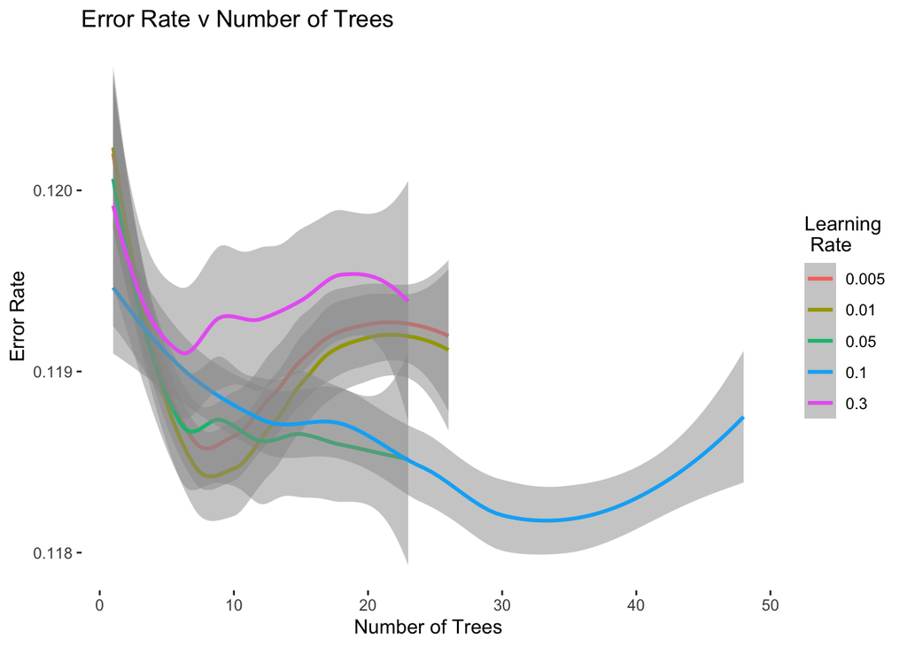

```r
# Plot lines
g_8 <- ggplot(plot_data, aes(x = iter, y = test_error_mean, color = eta))+
  geom_smooth(alpha = 0.5) +
  theme_bw() + # Set theme
  theme(panel.grid.major = element_blank(), # Remove grid
        panel.grid.minor = element_blank(), # Remove grid
        panel.border = element_blank(), # Remove grid
        panel.background = element_blank()) + # Remove grid
  labs(x = "Number of Trees", title = "Error Rate v Number of Trees",
       y = "Error Rate", color = "Learning \n Rate")  # Set labels
g_8
```

#I think this is an interesting plot. I would say the best is when ETA is at 0.1 . I am now going to do a final model.

```r
set.seed(888888)
bst_final <- xgboost(data = dtrain, # Set training data



              eta = 0.1, # Set learning rate
              max.depth =  5, # Set max depth
              min_child_weight = 10, # Set minimum number of samples in node to split
              gamma = 0, # Set minimum loss reduction for split
              subsample =  0.9, # Set proportion of training data to use in tree
              colsample_bytree = 0.8, # Set number of variables to use in each tree

              nrounds = 1000, # Set number of rounds
              early_stopping_rounds = 20, # Set number of rounds to stop at if there is no improvement

              verbose = 1, # 1 - Prints out fit
              nthread = 1, # Set number of parallel threads
              print_every_n = 20, # Prints out result every 20th iteration

              objective = "binary:logistic", # Set objective
              eval_metric = "auc",
              eval_metric = "error") # Set evaluation metric to use
```

```
## Multiple eval metrics are present. Will use train_error for early stopping.
## Will train until train_error hasn't improved in 20 rounds.
##
```

#OK now its time to see the model performance on the dataset

```r
library(OptimalCutpoints)

boost_preds_1 <- predict(bst_final, dtest) # Create predictions for xgboost model

# Convert predictions to classes, using optimal cut-off
boost_pred_class <- rep("0", length(boost_preds_1))
boost_pred_class[boost_preds_1 >= 0.5] <- "1"


t <- table(boost_pred_class, test_dat$BillboardHot) # Create table
confusionMatrix(t, positive = "1") # Produce confusion matrix
```

```
## Confusion Matrix and Statistics
##
##
## boost_pred_class    0    1
##                0 1728  227
##                1   34   11
##
##                Accuracy : 0.8695
##                  95% CI : (0.8539, 0.884)
##     No Information Rate : 0.881
##     P-Value [Acc > NIR] : 0.9462
##
##                   Kappa : 0.0415
##
##  Mcnemar's Test P-Value : <2e-16
##
##             Sensitivity : 0.04622
##             Specificity : 0.98070
##          Pos Pred Value : 0.24444
##          Neg Pred Value : 0.88389
##              Prevalence : 0.11900
##          Detection Rate : 0.00550
##    Detection Prevalence : 0.02250
##       Balanced Accuracy : 0.51346
##
##        'Positive' Class : 1
##
```

#The result shows the balanced accuracy when a cutoff point is at 0.5. But I would like to lower the cutoff rate to 0.1 to increase its usefulness.

```r
boost_preds_1 <- predict(bst_final, dtest) # Create predictions for xgboost model

# Convert predictions to classes, using optimal cut-off
boost_pred_class <- rep("0", length(boost_preds_1))
boost_pred_class[boost_preds_1 >= 0.1] <- "1"


t <- table(boost_pred_class, test_dat$BillboardHot) # Create table
confusionMatrix(t, positive = "1") # Produce confusion matrix
```

```
## Confusion Matrix and Statistics
##
##
## boost_pred_class    0    1
##                0 1293  149
##                1  469   89
##
##                Accuracy : 0.691
##                  95% CI : (0.6702, 0.7112)
##     No Information Rate : 0.881
##     P-Value [Acc > NIR] : 1
##
##                   Kappa : 0.0681
##
##  Mcnemar's Test P-Value : <2e-16
##
##             Sensitivity : 0.3739
##             Specificity : 0.7338
##          Pos Pred Value : 0.1595
##          Neg Pred Value : 0.8967
##              Prevalence : 0.1190
##          Detection Rate : 0.0445
##    Detection Prevalence : 0.2790
##       Balanced Accuracy : 0.5539
##
##        'Positive' Class : 1
##
```

#Now here I can see that the balanced accuracy rate has increased, which is good news!

#Cheking for imbalanced data

```r
summary(as.factor(train_dat$BillboardHot))
```

```
##    0    1
## 7047  954
```

```r
zero_weight <- 954/7047 # Calculate proportion of positive samples in data
weight_vec <- rep(1, nrow(train_dat)) # Create weight vector
weight_vec[which(train_dat$BillboardHot == 0)] <- zero_weight # Assign weight for negative samples
sum(weight_vec[which(train_dat$BillboardHot == 1)]) # Check 1 class weight
```

```
## [1] 954
```

```r
sum(weight_vec[which(train_dat$BillboardHot == 0)])
```

```
## [1] 954
```

```r
set.seed(888888)
bst_bal <- xgboost(data = dtrain, # Set training data

              eta = 0.1, # Set learning rate
              max.depth =  5, # Set max depth
              min_child_weight = 10, # Set minimum number of samples in node to split
              gamma = 0, # Set minimum loss reduction for split
              subsample =  0.9, # Set proportion of training data to use in tree
              colsample_bytree = 0.8, # Set number of variables to use in each tree

              nrounds = 1000, # Set number of rounds
              early_stopping_rounds = 20, # Set number of rounds to stop at if there is no improvement

              verbose = 1, # 1 - Prints out fit
              nthread = 1, # Set number of parallel threads
              print_every_n = 20, # Prints out result every 20th iteration

              weight = weight_vec, # Set weights

              objective = "binary:logistic", # Set objective
              eval_metric = "auc",
              eval_metric = "error") # Set evaluation metric to use
```

```
## Multiple eval metrics are present. Will use train_error for early stopping.
## Will train until train_error hasn't improved in 20 rounds.
##
```

#Check for imbalanced data

```r
# Check results
set.seed(888888)
boost_preds_bal <- predict(bst_bal, dtrain) # Create predictions for XGBoost model on training data

pred_dat <- cbind.data.frame(boost_preds_bal , train_dat$BillboardHot)#
names(pred_dat) <- c("predictions", "response")
oc<- optimal.cutpoints(X = "predictions",
                       status = "response",
                       tag.healthy = 0,
                       data = pred_dat,
                       methods = "MaxEfficiency")

boost_preds_bal <- predict(bst_bal, dtest) # Create predictions for XGBoost model

pred_dat <- cbind.data.frame(boost_preds_bal , test_dat$BillboardHot)#
# Convert predictions to classes, using optimal cut-off
boost_pred_class <- rep(0, length(boost_preds_bal))
boost_pred_class[boost_preds_bal >= oc$MaxEfficiency$Global$optimal.cutoff$cutoff[1]] <- 1


t <- table(boost_pred_class, test_dat$BillboardHot) # Create table
confusionMatrix(t, positive = "1") # Produce confusion matrix
```

```
## Confusion Matrix and Statistics
##
##
## boost_pred_class    0    1
##                0 1663  207
##                1   99   31
##
##                Accuracy : 0.847
##                  95% CI : (0.8305, 0.8625)
##     No Information Rate : 0.881
##     P-Value [Acc > NIR] : 1
##
##                   Kappa : 0.0921
##
##  Mcnemar's Test P-Value : 9.548e-10
##
##             Sensitivity : 0.1303
##             Specificity : 0.9438
##          Pos Pred Value : 0.2385
##          Neg Pred Value : 0.8893
##              Prevalence : 0.1190
##          Detection Rate : 0.0155
##    Detection Prevalence : 0.0650
##       Balanced Accuracy : 0.5370
##
##        'Positive' Class : 1
##
```

#The results shows a slightly lower balanced accuracy rate, but thats ok, I will take that.

#Now, I woud like to determine the variable importance

```r
shap.score.rank <- function(xgb_model = xgb_mod, shap_approx = TRUE,
                            X_train = mydata$train_mm){
  require(xgboost)
  require(data.table)
  shap_contrib <- predict(xgb_model, X_train,
                          predcontrib = TRUE, approxcontrib = shap_approx)
  shap_contrib <- as.data.table(shap_contrib)
  shap_contrib[,BIAS:=NULL]
  cat('make SHAP score by decreasing order\n\n')
  mean_shap_score <- colMeans(abs(shap_contrib))[order(colMeans(abs(shap_contrib)), decreasing = T)]
  return(list(shap_score = shap_contrib,
              mean_shap_score = (mean_shap_score)))
}

# a function to standardize feature values into same range
std1 <- function(x){
  return ((x - min(x, na.rm = T))/(max(x, na.rm = T) - min(x, na.rm = T)))
}


# prep shap data
shap.prep <- function(shap  = shap_result, X_train = mydata$train_mm, top_n){
  require(ggforce)
  # descending order
  if (missing(top_n)) top_n <- dim(X_train)[2] # by default, use all features
  if (!top_n%in%c(1:dim(X_train)[2])) stop('supply correct top_n')
  require(data.table)
  shap_score_sub <- as.data.table(shap$shap_score)
  shap_score_sub <- shap_score_sub[, names(shap$mean_shap_score)[1:top_n], with = F]
  shap_score_long <- melt.data.table(shap_score_sub, measure.vars = colnames(shap_score_sub))

  # feature values: the values in the original dataset
  fv_sub <- as.data.table(X_train)[, names(shap$mean_shap_score)[1:top_n], with = F]
  # standardize feature values
  fv_sub_long <- melt.data.table(fv_sub, measure.vars = colnames(fv_sub))
  fv_sub_long[, stdfvalue := std1(value), by = "variable"]
  # SHAP value: value
  # raw feature value: rfvalue;
  # standarized: stdfvalue
  names(fv_sub_long) <- c("variable", "rfvalue", "stdfvalue" )
  shap_long2 <- cbind(shap_score_long, fv_sub_long[,c('rfvalue','stdfvalue')])
  shap_long2[, mean_value := mean(abs(value)), by = variable]
  setkey(shap_long2, variable)
  return(shap_long2)
}

plot.shap.summary <- function(data_long){
  x_bound <- max(abs(data_long$value))
  require('ggforce') # for `geom_sina`
  plot1 <- ggplot(data = data_long)+
    coord_flip() +
    # sina plot:
    geom_sina(aes(x = variable, y = value, color = stdfvalue)) +
    # print the mean absolute value:
    geom_text(data = unique(data_long[, c("variable", "mean_value"), with = F]),
              aes(x = variable, y=-Inf, label = sprintf("%.3f", mean_value)),
              size = 3, alpha = 0.7,
              hjust = -0.2,
              fontface = "bold") + # bold
    # # add a "SHAP" bar notation
    # annotate("text", x = -Inf, y = -Inf, vjust = -0.2, hjust = 0, size = 3,
    #          label = expression(group("|", bar(SHAP), "|"))) +
    scale_color_gradient(low="#FFCC33", high="#6600CC",
                         breaks=c(0,1), labels=c("Low","High")) +
    theme_bw() +
    theme(axis.line.y = element_blank(), axis.ticks.y = element_blank(), # remove axis line
          legend.position="bottom") +
    geom_hline(yintercept = 0) + # the vertical line
    scale_y_continuous(limits = c(-x_bound, x_bound)) +
    # reverse the order of features
    scale_x_discrete(limits = rev(levels(data_long$variable))
    ) +
    labs(y = "SHAP value (impact on model output)", x = "", color = "Feature value")
  return(plot1)
}

var_importance <- function(shap_result, top_n=10)
{
  var_importance=tibble(var=names(shap_result$mean_shap_score), importance=shap_result$mean_shap_score)

  var_importance=var_importance[1:top_n,]

  ggplot(var_importance, aes(x=reorder(var,importance), y=importance)) +
    geom_bar(stat = "identity") +
    coord_flip() +
    theme_light() +
    theme(axis.title.y=element_blank())
}
```

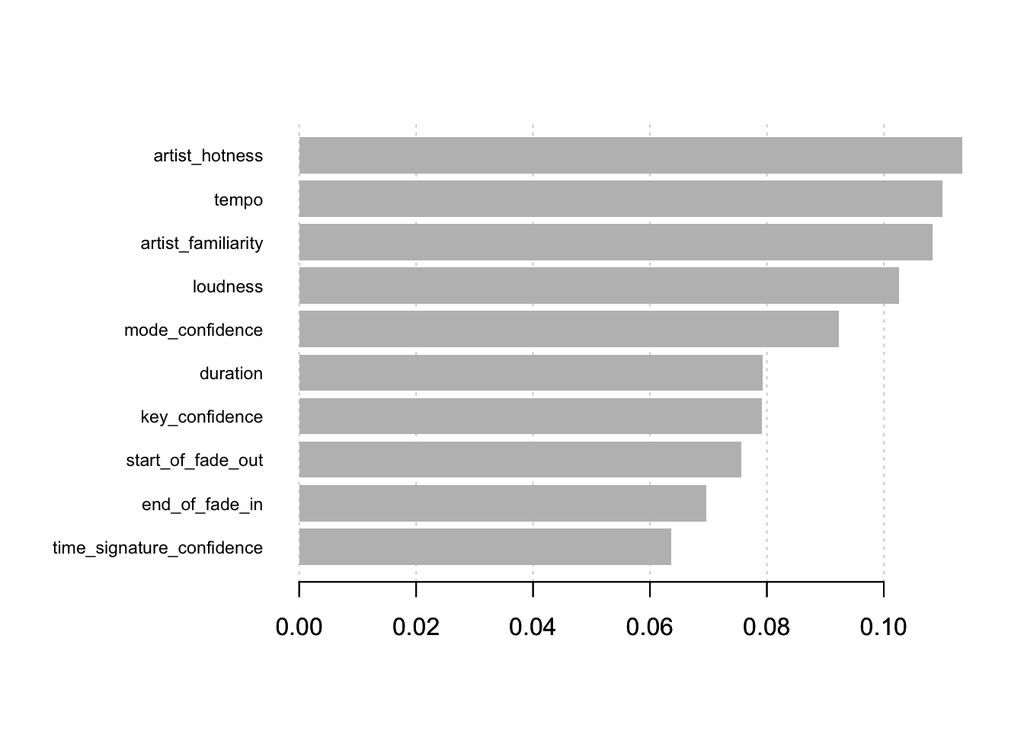

```r
# Extract importance
imp_mat <- xgb.importance(model = bst_final)
# Plot importance (top 10 variables)
xgb.plot.importance(imp_mat, top_n = 10)
```

#Hmm.. seems like artist hotness is the most important variableaccording to XGBoost.

#Trying to run a SHAP to see the affect of each variable

```r
x_vars <- model.matrix(MusicDatasetMSD$BillboardHot ~., data = MusicDatasetMSD[,1:15])[,-1]
# Create DMatrix
dtrain <- xgb.DMatrix(data =x_vars, label = MusicDatasetMSD$BillboardHot)
# Fit XGBoost
bst_SHAP <- xgboost(data = dtrain, # Set training data
                    nrounds = 100, # Set number of rounds
                    verbose = 1, # 1 - Prints out fit
                    print_every_n = 20, # Prints out result every 20th iteration
                    objective = "binary:logistic", # Set objective
                    eval_metric = "auc",
                    eval_metric = "error") # Set evaluation metric to use
shap_values <- predict(bst_final,
                    x_vars,
                    predcontrib = TRUE,
                    approxcontrib = F)

shap_values[1,]
```

```
##        artist_familiarity            artist_hotness                  duration
##              -0.348601520              -0.102903679              -0.366429448
##            end_of_fade_in                       key            key_confidence
##              -0.100484706              -0.064136416              -0.184132367
##                  loudness                      mode           mode_confidence
##              -0.267183691               0.007785974               0.061266486
##         start_of_fade_out                     tempo            time_signature
##              -0.533090770               0.241606116              -0.024532638
## time_signature_confidence                      year                      BIAS
##              -0.114867069               0.032671623              -2.009820700
```

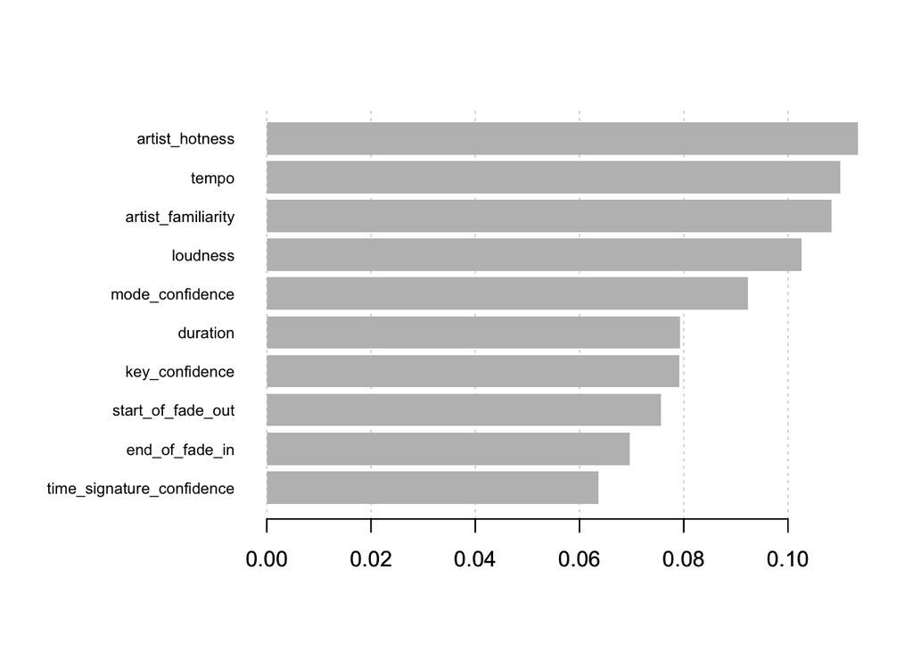

```r
# Extract standard importance
imp_mat_SHAP <- xgb.importance(model = bst_final)
# Plot standard importance (top 10 variables)
xgb.plot.importance(imp_mat_SHAP, top_n = 10)
```

#With XGBoost. Artist hotness is the most imortant variable.

```r
library(ggforce)
library(pROC)
shap_result <- shap.score.rank(xgb_model = bst_final,
                X_train =as.matrix(train_dat[, 1:14]),
                shap_approx = F)
```

```
## make SHAP score by decreasing order
```

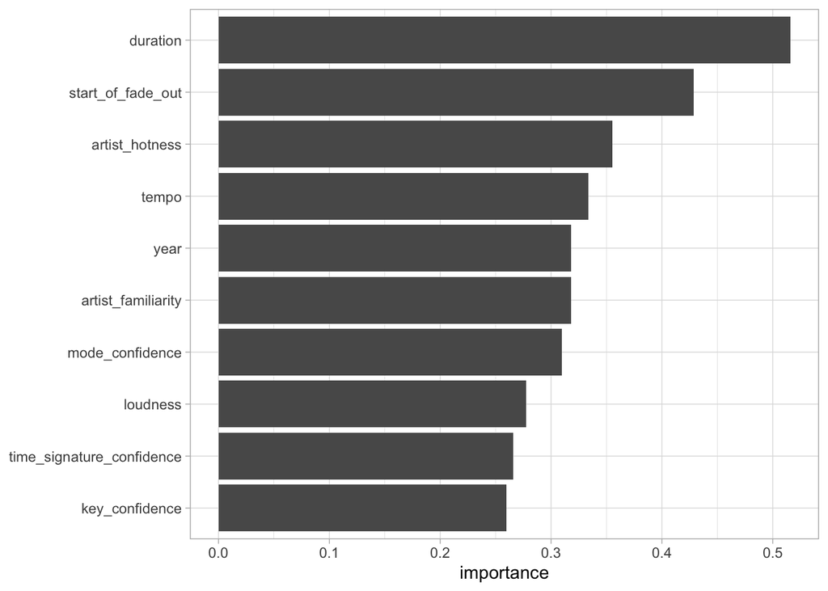

```r
var_importance(shap_result, top_n=10)
```

#With SHAP, duration (surprisingly) is the most important variable, leading with a wide margin to the second most important variable. I find this to be pretty interesting as I will ever thought of duration as the most important factor.

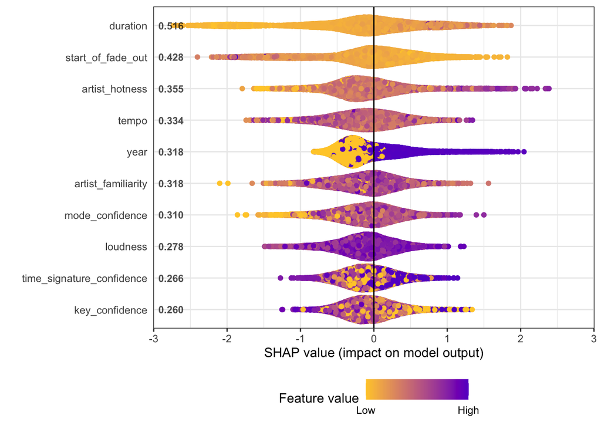

```r
shap_long = shap.prep(shap = shap_result,
                           X_train = as.matrix(train_dat[, 1:14]),
                           top_n = 10)


plot.shap.summary(data_long = shap_long)
```

#The SHAP value plot suggest that duration does infact have the highest impact on model output, even though its feature value is not the highest . On the other hand, artist hotness stretches furthest to the highest level of the feature value but came in third overall.

#Time signature plot

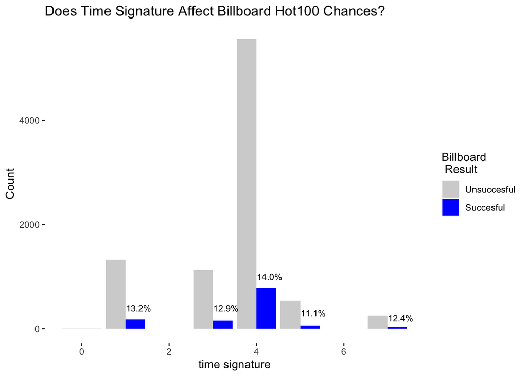

```r
# Count results
temp <- as.data.frame(count(MusicDatasetMSD, time_signature, BillboardHot))
# Create transperancy

#temp$alpha_vec <- c(0.7, 1, 0.7, 0.5)
# Create plot
g_9 <- ggplot(temp, aes(x = time_signature, fill = factor(BillboardHot), y = n)) + #alpha = alpha_vec)) +
  geom_bar(position = "dodge", stat = "identity") +
  theme(panel.grid.major = element_blank(), # Remove grid
        panel.grid.minor = element_blank(), # Remove grid
        panel.border = element_blank(), # Remove grid
        panel.background = element_blank()) +
  scale_fill_manual(values = c("1" = "blue", "0" = "lightgrey"),
                    labels = c("1" = "Succesful", "0" = "Unsuccesful")) +
  labs(x = "time signature", y = "Count", fill = "Billboard \n Result",
       title = "Does Time Signature Affect Billboard Hot100 Chances?")  +
  annotate("text", x = 1.3, y = 400, label = "13.2%", size = 3) +
  annotate("text", x = 3.3, y = 400, label = "12.9%", size = 3) +
  annotate("text", x = 4.3, y = 1000, label = "14.0%", size = 3) +
  annotate("text", x = 5.3, y = 300, label = "11.1%", size = 3) +
  annotate("text", x = 7.3, y = 200, label = "12.4%", size = 3) +
  guides(alpha = "none")
g_9
```

#The time signature plot proved that if does affect the chances of a song’s success, with the highest probability at 4/4.

#Mode plot

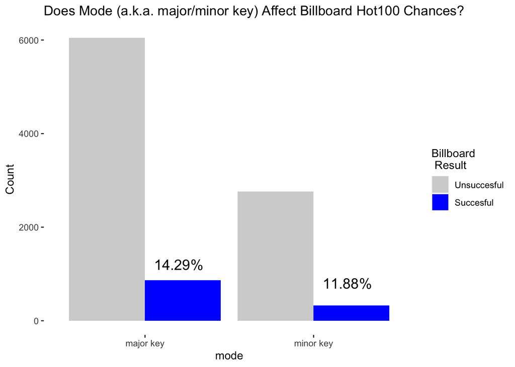

```r
# Count results
temp_2 <- as.data.frame(count(MusicDatasetMSD, mode, BillboardHot))
# Create transperancy

temp_2<- temp_2 %>%
  mutate(`mode` = replace(`mode`, `mode` == '1', 'major key'))%>%
  mutate(`mode` = replace(`mode`, `mode` == '0', 'minor key'))
#temp$alpha_vec <- c(0.7, 1, 0.7, 0.5)
# Create plot
g_10 <- ggplot(temp_2, aes(x = mode, fill = factor(BillboardHot), y = n ))+ #, alpha = 0.9)) +
  geom_bar(position = "dodge", stat = "identity") +
  theme(panel.grid.major = element_blank(), # Remove grid
        panel.grid.minor = element_blank(), # Remove grid
        panel.border = element_blank(), # Remove grid
        panel.background = element_blank()) +
  scale_fill_manual(values = c("1" = "blue", "0" = "lightgrey"),
                    labels = c("1" = "Succesful", "0" = "Unsuccesful")) +
  labs(x = "mode", y = "Count", fill = "Billboard \n Result",
         title = "Does Mode (a.k.a. major/minor key) Affect Billboard Hot100 Chances?") +
  annotate("text", x = 1.2, y = 1200, label = "14.29%", size = 5) +
  annotate("text", x = 2.2, y = 800, label = "11.88%", size = 5) +

  guides(alpha = "none")
g_10
```

#The mode plot suggest that songwriters write songs in major keys to have a higher chance of success

#Key plot

```r
# Count results
temp_3 <- as.data.frame(count(MusicDatasetMSD, key, BillboardHot))
# Create transperancy
library(tidyverse)
```

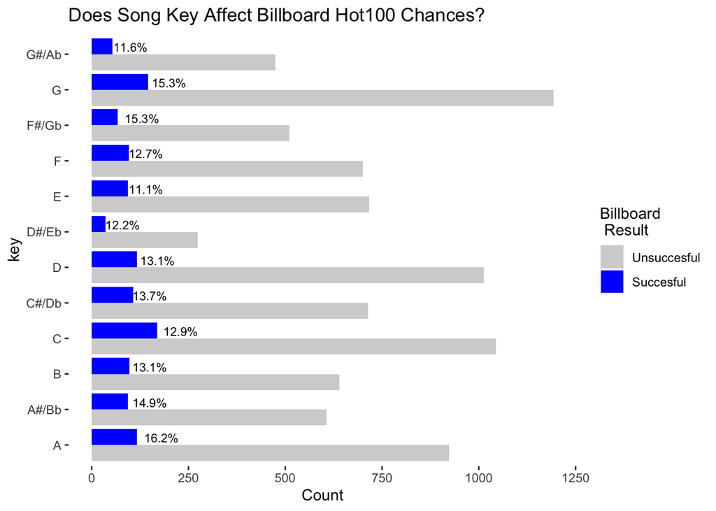

```r
library(dplyr)
temp_3 <- temp_3 %>%
  mutate(`key` = replace(`key`, `key` == '0', 'C')) %>%
  mutate(`key` = replace(`key`, `key` == '1', 'C#/Db')) %>%
  mutate(`key` = replace(`key`, `key` == '2', 'D')) %>%
  mutate(`key` = replace(`key`, `key` == '3', 'D#/Eb')) %>%
  mutate(`key` = replace(`key`, `key` == '4', 'E')) %>%
  mutate(`key` = replace(`key`, `key` == '5', 'F')) %>%
  mutate(`key` = replace(`key`, `key` == '6', 'F#/Gb')) %>%
  mutate(`key` = replace(`key`, `key` == '7', 'G')) %>%
  mutate(`key` = replace(`key`, `key` == '8', 'G#/Ab')) %>%
  mutate(`key` = replace(`key`, `key` == '9', 'A')) %>%
  mutate(`key` = replace(`key`, `key` == '10', 'A#/Bb')) %>%
  mutate(`key` = replace(`key`, `key` == '11', 'B'))
#temp$alpha_vec <- c(0.7, 1, 0.7, 0.5)
# Create plot
g_11 <- ggplot(temp_3, aes(x = key, fill = factor(BillboardHot), y = n)) + #alpha = alpha_vec)) +
  geom_bar(position = "dodge", stat = "identity") +
  theme(panel.grid.major = element_blank(), # Remove grid
        panel.grid.minor = element_blank(), # Remove grid
        panel.border = element_blank(), # Remove grid
        panel.background = element_blank(),
        panel.grid.major.y = element_blank()) +
  scale_fill_manual(values = c("1" = "blue", "0" = "lightgrey"),
                    labels = c("1" = "Succesful", "0" = "Unsuccesful")) +
  labs(x = "key", y = "Count", fill = "Billboard \n Result",
       title = "Does Song Key Affect Billboard Hot100 Chances?")  +
  annotate("text", x = 1.2, y = 180, label = "16.2%", size = 3) +
  annotate("text", x = 2.2, y = 150, label = "14.9%", size = 3) +
  annotate("text", x = 12.2, y = 100, label = "11.6%", size = 3) +
  annotate("text", x = 3.2, y = 150, label = "13.1%", size = 3) +
  annotate("text", x = 4.2, y = 230, label = "12.9%", size = 3) +
  annotate("text", x = 5.2, y = 150, label = "13.7%", size = 3) +
  annotate("text", x = 6.2, y = 170, label = "13.1%", size = 3) +
  annotate("text", x = 7.2, y = 80, label = "12.2%", size = 3) +
  annotate("text", x = 8.2, y = 140, label = "11.1%", size = 3) +
  annotate("text", x = 9.2, y = 140, label = "12.7%", size = 3) +
  annotate("text", x = 10.2, y = 130, label = "15.3%", size = 3) +
  annotate("text", x = 11.2, y = 200, label = "15.3%", size = 3) +
  guides(alpha = "none")+
  coord_flip()
g_11
```

#The key plot suggest that a song written in the key of ‘A’ has the highest chance of being successful.